# Práctica 1: Estadística descriptiva

Estadística - Curso 2023/2024

# Introducción y definición de objetivos

El principal objetivo de nuestro estudio estadístico es dar respuesta y conocer las distintas relaciones existentes entre el precio de las casas en Nueva York y las distintas variables que puedan llegar a afectar a este indicador.

Como podemos apreciar en el dataset hay numerosas variables, pero algunas de ellas serán descartadas en nuestra investigación debido a que son variables de complejo estudio. Estas variables descartadas son la latitud y la longitud. Hemos descartado más variables, pero se comentarán a lo largo del estudio.

Nos centraremos en determinadas relaciones entre variables según su incertidumbre, correlación… Todo esto lo iremos viendo mediante el transcurso del estudio estadístico. Gran ejemplo de estas relaciones de interés podría ser la relación del precio de las casas con el número de habitaciones, baños, pies cuadrados, siendo esta la de mayor interés; al igual que con la propia localización del domicilio. Entre estas variables de localización, nos quedaremos con “FORMATED_ADDRESS”, ya que es la variable de localización más precisa, completa y que consideramos que nos puede ser más útil en nuestro estudio estadístico. Descartaremos, al no proporcionarnos gran información relevante, las siguientes variables de localización: “ADDRESS”, “MAIN_ADDRESS”, “STATE”, “STREET_NAME”, “LONG_NAME”.

Cabe destacar que nos han sorprendido ciertos datos en nuestro estudio estadístico. Dentro de la variable asociada al número de baños encontramos un dato que en un principio nos pareció algo extraño (2.373861). Evaluamos la posibilidad de que este dato pudiese llegar a ser una anomalía, pero investigando en internet encontramos que cada baño completo es ponderado con el valor de 1, mientras que un aseo con 0.373861. Sumando el número de baños completos y aseos, se llega a los valores representados en la variable “BATH”.

También investigamos acerca de la veracidad de nuestros datos con el objetivo de descartar cualquier dato anómalo. Por ejemplo, buscamos en internet las casas con un determinado número de baños en Nueva York. En algunos casos, los datos nos variaron, por ejemplo, una casa de 16 baños que en realidad contaba con 17. Pero, por lo general, los datos son completamente verídicos.

# Importación de datos y carga de paquetes

```r
library(tidyverse)
library(summarytools)
library(GGally)
library(csvread)
library(knitr)
library(corrplot)
library(htmltools)
NYHouse <- read.csv("NY-House-Dataset.csv")
```

# Diccionario de datos

- `BROKERTITLE`: Nombre del agente comercial.
  - Variable tipo: Categórica multinivel.
- `TYPE`: Tipo de casa.
  - Variable tipo: Categórica multinivel.
- `PRICE`: Precio de la casa.
  - Variable tipo: Numérica continua.
- `BEDS`: Número de habitaciones.
  - Variable tipo: Numérica discreta.
- `BATH`: Número de baños.
  - Variable tipo: Numérica continua.
- `PROPERTYSQFT`: Pies cuadrados de la casa.
  - Variable tipo: Numérica continua.
- `ADDRESS`: Dirección de la casa (calle).
  - Variable tipo: Categórica multinivel.
- `STATE`: Barrio y código postal.
  - Variable tipo: Categórica multinivel.
- `MAIN_ADDRESS`: Dirección completa de la casa (calle + barrio + código postal).
  - Variable tipo: Identificador.
- `ADMINISTRATIVE_AREA_LEVEL_2`: Area administrativa de nivel 2.
  - Variable tipo: Categórica multinivel.
- `LOCALITY`: Localidad.
  - Variable tipo: Categórica multinivel.
- `SUBLOCALITY`: Barrio/distrito.
  - Variable tipo: Categórica multinivel.
- `STREET_NAME`: Nombre de la calle.
  - Variable tipo: Categórica multinivel.
- `LONG_NAME`: Nombre largo de la calle.
  - Variable tipo: Categórica multinivel.
- `FORMATTED_ADDRESS`: Dirección completa/formal/específica.
  - Variable tipo: Identificador.
- `LATITUDE`: Latitud.
  - Variable tipo: Numérica continua.
- `LONGITUDE`: Longitud.
  - Variable tipo: Numérica continua.

# Análisis exploratorio de datos.

A continuación, vamos a realizar el estudio de todas las variables de nuestro dataset. Este estudio constará de dos partes:

## Análisis univariante.

### Estudio de la variable BROKERTITLE

```r
num_respuestas_BROKERTITLE <- length(unique(NYHouse$BROKERTITLE))
cat("La cantidad de respuestas obtenidas es:", num_respuestas_BROKERTITLE)
```

```
## La cantidad de respuestas obtenidas es: 1036
```

Como podemos observar, esta variable no tiene sentido analizarla, ya que contamos con muchos valores.

### Estudio de la variable TYPE

```r
num_respuestas_TYPE <- length(unique(NYHouse$TYPE))
cat("La cantidad de respuestas obtenidas es:", num_respuestas_TYPE)
```

```
## La cantidad de respuestas obtenidas es: 13
```

Como podemos observar, aquí si tiene sentido realizar un estudio para poder ver que tipo de casa es la que más se vende. A continuación, con el siguiente código estudiaremos las frecuencias relativas y absolutas.

```r
tabla_frecuencias_type <- NYHouse |>
  count(TYPE) |>
  mutate(f = n / nrow(NYHouse), N = cumsum(n), F = cumsum(f))
tabla_frecuencias_ordenada3 <- tabla_frecuencias_type |>
  arrange(desc(n))
tabla_frecuencias_ordenada3$F <- cumsum(tabla_frecuencias_ordenada3$f)
tabla_frecuencias_ordenada3$N <- cumsum(tabla_frecuencias_ordenada3$n)
print(tabla_frecuencias_ordenada3)
```

```
##                          TYPE    n            f    N         F
## 1              Co-op for sale 1450 0.3020204124 1450 0.3020204
## 2              House for sale 1012 0.2107894189 2462 0.5128098
## 3              Condo for sale  891 0.1855863362 3353 0.6983962
## 4  Multi-family home for sale  727 0.1514267861 4080 0.8498230
## 5          Townhouse for sale  299 0.0622786919 4379 0.9121016
## 6                     Pending  243 0.0506144553 4622 0.9627161
## 7                  Contingent   88 0.0183295147 4710 0.9810456
## 8               Land for sale   49 0.0102062070 4759 0.9912518
## 9                    For sale   20 0.0041657988 4779 0.9954176
## 10                Foreclosure   14 0.0029160592 4793 0.9983337
## 11            Condop for sale    5 0.0010414497 4798 0.9993751
## 12                Coming Soon    2 0.0004165799 4800 0.9997917
## 13      Mobile house for sale    1 0.0002082899 4801 1.0000000
```

Para ello, utilizaremos una gráfica donde se podrán observar los datos con claridad en función de la frecuencia relativa. Crearemos la gráfica haciendo uso del siguiente código.

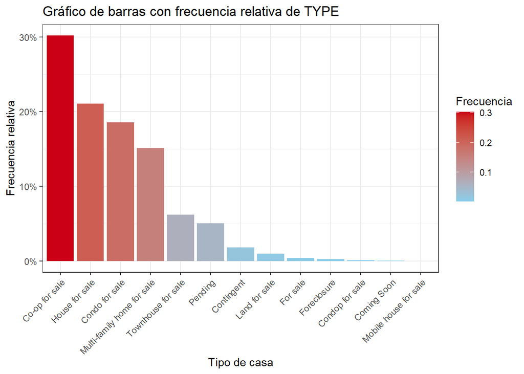

```r
NYHouse  |> group_by(TYPE) |>  summarise(Frequency = n()) |> mutate(Frequency = Frequency/sum(Frequency), TYPE = reorder(TYPE, -Frequency)) |> ggplot(aes(x = TYPE, y = Frequency)) + geom_bar(stat = "identity", aes(fill = Frequency)) + scale_y_continuous(labels = scales::percent) + theme_bw() + labs(title = "Gráfico de barras con frecuencia relativa de TYPE", x = "Tipo de casa", y = "Frecuencia relativa") + scale_fill_gradient("Frecuencia", low = "skyblue", high = "#CB0017") + theme(axis.text.x = element_text(angle = 45, hjust = 1))
```

A continuación, podemos hacer un gráfico con sus frecuencias absolutas con el siguiente código.

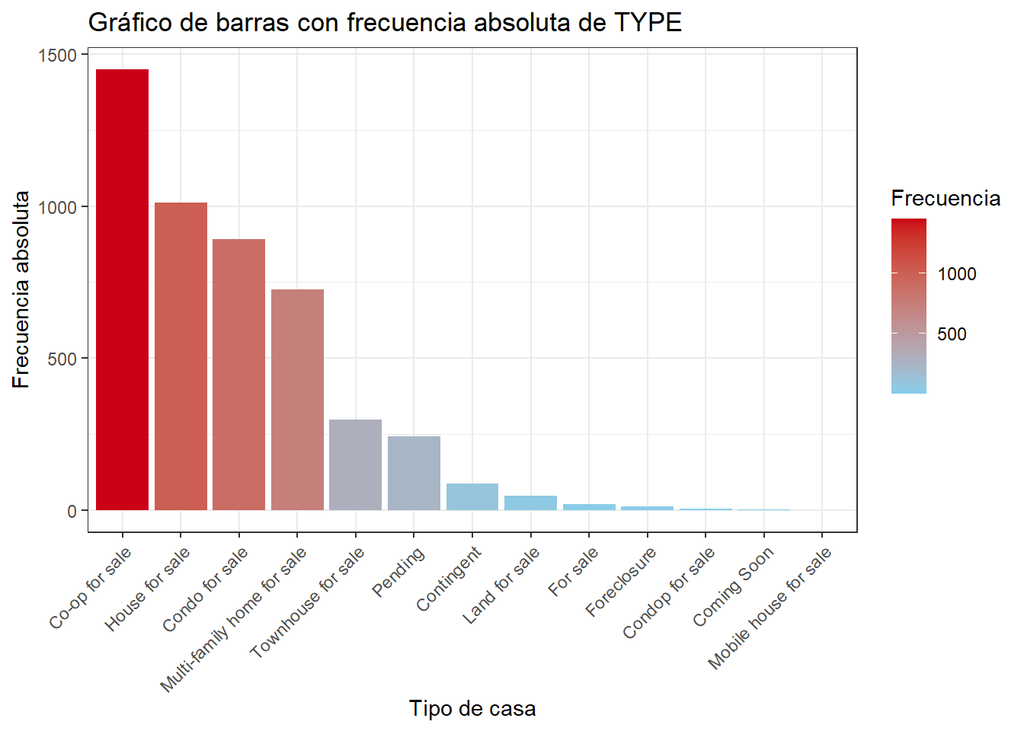

```r
NYHouse |>
  group_by(TYPE) |>
  summarise(Frequency = n()) |>
  mutate(TYPE = reorder(TYPE, -Frequency)) |>
  ggplot(aes(x = TYPE, y = Frequency)) +
  geom_bar(stat = "identity", aes(fill = Frequency)) +
  theme_bw() +
  labs(title = "Gráfico de barras con frecuencia absoluta de TYPE",
       x = "Tipo de casa",
       y = "Frecuencia absoluta") +
  scale_fill_gradient("Frecuencia", low = "skyblue", high = "#CB0017") +
  theme(axis.text.x = element_text(angle = 45, hjust = 1))
```

Como podemos observar, la mayor parte de los valores obtenidos ocurren en las cuatro primeras columnas de ambas gráficas ocupando el 84,98% de los casos y en términos numéricos representando 4080 de 4801 casos. Estos son: ‘’Co-op for sale’‘,’‘House for sale’‘,’‘Condo for sale’’ y ‘’Multi-family home for sale’’. Con estos datos podemos encontrar de manera aproximada los tipos de casa que más se venden en Nueva York.

### Estudio de la variable PRICE

```r
num_respuestas_PRICE<- length(unique(NYHouse$PRICE))
cat("La cantidad de respuestas obtenidas es:", num_respuestas_PRICE)
```

```
## La cantidad de respuestas obtenidas es: 1274
```

Como podemos observar, no tiene sentido realizar un estudio de esta variable continua. Entre las posibles soluciones encontramos la de discretizar la variable en percentiles (dividir en cien intervalos) pudiendo así realizar un estudio adecuado. Una vez discretizada la variable, realizamos un histograma con el siguiente código.

```r
intervalos <- seq(0, ceiling(max(NYHouse$PRICE) / 100000) * 100000, by = 100000)
tabla_frecuencias_price <- NYHouse %>%
  count(PRICE) %>%
  mutate(f = n / nrow(NYHouse)) %>%
  mutate(N = cumsum(n),
         F = cumsum(f))
tabla_frecuencias_price <- tabla_frecuencias_price %>%
  mutate(Intervalo = cut(PRICE, breaks = intervalos, right = FALSE)) %>%
  group_by(Intervalo) %>%
  summarise(n = sum(n),
            f = sum(f),
            N = sum(n),
            F = sum(f))
for (i in 2:nrow(tabla_frecuencias_price)) {
  tabla_frecuencias_price$N[i] <- tabla_frecuencias_price$N[i] + tabla_frecuencias_price$N[i - 1]
  tabla_frecuencias_price$F[i] <- tabla_frecuencias_price$F[i] + tabla_frecuencias_price$F[i - 1]
}
tabla_frecuencias_ordenada4 <- tabla_frecuencias_price %>%
  arrange(Intervalo)
print(tabla_frecuencias_ordenada4)
```

```
## # A tibble: 170 × 5
##    Intervalo         n       f     N       F
##    <fct>         <int>   <dbl> <int>   <dbl>
##  1 [0,1e+05)        18 0.00375    18 0.00375
##  2 [1e+05,2e+05)   158 0.0329    176 0.0367
##  3 [2e+05,3e+05)   401 0.0835    577 0.120
##  4 [3e+05,4e+05)   368 0.0767    945 0.197
##  5 [4e+05,5e+05)   302 0.0629   1247 0.260
##  6 [5e+05,6e+05)   363 0.0756   1610 0.335
##  7 [6e+05,7e+05)   390 0.0812   2000 0.417
##  8 [7e+05,8e+05)   359 0.0748   2359 0.491
##  9 [8e+05,9e+05)   303 0.0631   2662 0.554
## 10 [9e+05,1e+06)   298 0.0621   2960 0.617
## # ℹ 160 more rows
```

Procedemos a realizar el histograma completo:

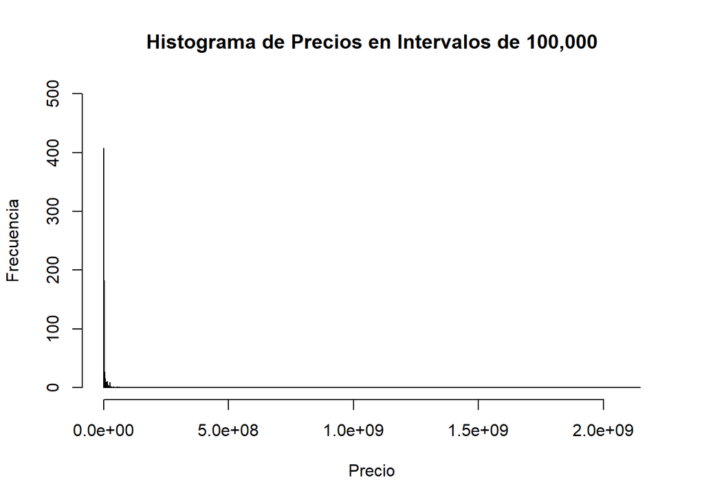

```r
intervalos <- seq(0, ceiling(max(NYHouse$PRICE) / 100000) * 100000, by = 100000)
NYHouse$intervalo_price <- cut(NYHouse$PRICE, breaks = intervalos, labels = FALSE)
frecuencia_por_intervalo <- table(NYHouse$intervalo_price)
hist(NYHouse$PRICE, breaks = intervalos, xlab = "Precio", ylab = "Frecuencia", main = "Histograma de Precios en Intervalos de 100,000", freq = TRUE, ylim = c(0, 500), col = "skyblue", border = "black")
```

Como podemos observar, este histograma es ilegible. Los valores obtenidos estan concentrados mayoritariamente en un intervalo de 0 a 4000000 donde se verá reflejado en la siguiente gráfica :

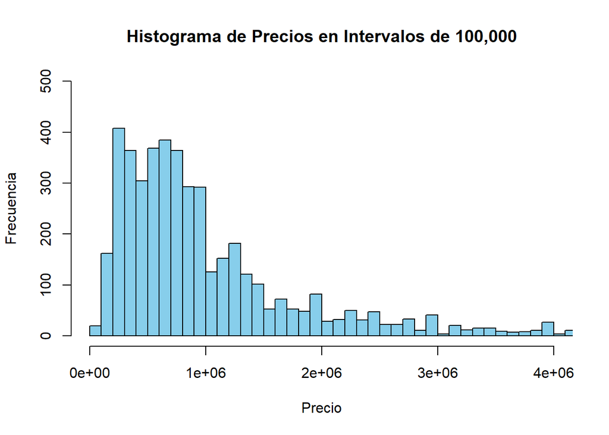

```r
intervalos <- seq(0, ceiling(max(NYHouse$PRICE) / 100000) * 100000, by = 100000)
NYHouse$intervalo_price <- cut(NYHouse$PRICE, breaks = intervalos, labels = FALSE)
frecuencia_por_intervalo <- table(NYHouse$intervalo_price)
hist(NYHouse$PRICE, breaks = intervalos, xlab = "Precio", ylab = "Frecuencia", main = "Histograma de Precios en Intervalos de 100,000", freq = TRUE, ylim = c(0, 500), xlim = c(0,4000000), col = "skyblue", border = "black")
```

Además de este histograma debemos realizar un resumen númerico a partir del cual podremos comprender los gráficos con mayor facilidad.

```r
NYHouse |> select(PRICE) |> descr() |> kable(digits = 2)
```

|  | PRICE |
| --- | --- |
| Mean | 2.356940e+06 |
| Std.Dev | 3.135525e+07 |
| Min | 2.494000e+03 |
| Q1 | 4.990000e+05 |
| Median | 8.250000e+05 |
| Q3 | 1.495000e+06 |
| Max | 2.147484e+09 |
| MAD | 6.315876e+05 |
| IQR | 9.960000e+05 |
| CV | 1.330000e+01 |
| Skewness | 6.676000e+01 |
| SE.Skewness | 4.000000e-02 |
| Kurtosis | 4.560200e+03 |
| N.Valid | 4.801000e+03 |
| Pct.Valid | 1.000000e+02 |

### Estudio de la variable BEDS

```r
num_respuestas_BEDS <- length(unique(NYHouse$BEDS))
cat("La cantidad de respuestas obtenidas es:", num_respuestas_BEDS)
```

```
## La cantidad de respuestas obtenidas es: 27
```

Como observamos, aquí si tiene sentido realizar un estudio para poder ver el número de habitaciones que más se vende. A continuación, con el siguiente código esudiaremos las frecuencias relativas y absolutas.

```r
tabla_frecuencias_beds <- NYHouse |>
  count(BEDS) |>
  mutate(f = n / nrow(NYHouse), N = cumsum(n), F = cumsum(f))
tabla_frecuencias_ordenada4 <- tabla_frecuencias_beds |>
  arrange(desc(n))
tabla_frecuencias_ordenada4$F <- cumsum(tabla_frecuencias_ordenada4$f)
tabla_frecuencias_ordenada4$N <- cumsum(tabla_frecuencias_ordenada4$n)
print(tabla_frecuencias_ordenada4)
```

```
##    BEDS    n            f    N         F
## 1     3 1456 0.3032701521 1456 0.3032702
## 2     2  995 0.2072484899 2451 0.5105186
## 3     1  820 0.1707977505 3271 0.6813164
## 4     4  570 0.1187252656 3841 0.8000417
## 5     5  360 0.0749843783 4201 0.8750260
## 6     6  271 0.0564465736 4472 0.9314726
## 7     7  105 0.0218704437 4577 0.9533431
## 8     8   84 0.0174963549 4661 0.9708394
## 9     9   39 0.0081233076 4700 0.9789627
## 10   12   23 0.0047906686 4723 0.9837534
## 11   10   21 0.0043740887 4744 0.9881275
## 12   11   20 0.0041657988 4764 0.9922933
## 13   14    7 0.0014580296 4771 0.9937513
## 14   13    5 0.0010414497 4776 0.9947928
## 15   15    5 0.0010414497 4781 0.9958342
## 16   16    4 0.0008331598 4785 0.9966674
## 17   20    3 0.0006248698 4788 0.9972922
## 18   24    3 0.0006248698 4791 0.9979171
## 19   32    2 0.0004165799 4793 0.9983337
## 20   18    1 0.0002082899 4794 0.9985420
## 21   19    1 0.0002082899 4795 0.9987503
## 22   30    1 0.0002082899 4796 0.9989586
## 23   35    1 0.0002082899 4797 0.9991668
## 24   36    1 0.0002082899 4798 0.9993751
## 25   40    1 0.0002082899 4799 0.9995834
## 26   42    1 0.0002082899 4800 0.9997917
## 27   50    1 0.0002082899 4801 1.0000000
```

A continuación, realizaremos un histograma mediante el siguiente código.

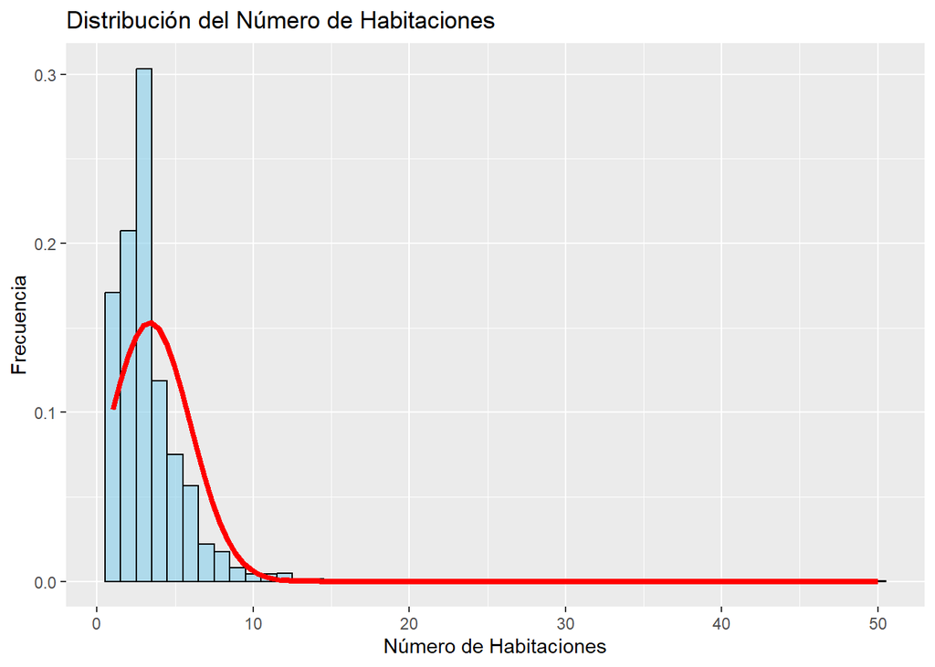

```r
datos <- NYHouse$BEDS
ggplot(data.frame(x = datos), aes(x = x)) +
  geom_histogram(binwidth = 1, fill = "skyblue", color = "black",
                 aes(y = ..density..), alpha = 0.6) +
  stat_function(fun = dnorm, args = list(mean = mean(datos),
                                         sd = sd(datos)), color = "red", size = 1.5) +
  labs(title = "Distribución del Número de Habitaciones",
       x = "Número de Habitaciones",
       y = "Frecuencia")
```

Además de este histograma debemos realizar un resumen númerico a partir del cual podremos comprender los gráficos con facilidad.

```r
NYHouse |> select(BEDS) |> descr() |> kable(digits = 2)
```

|  | BEDS |
| --- | --- |
| Mean | 3.36 |
| Std.Dev | 2.60 |
| Min | 1.00 |
| Q1 | 2.00 |
| Median | 3.00 |
| Q3 | 4.00 |
| Max | 50.00 |
| MAD | 1.48 |
| IQR | 2.00 |
| CV | 0.78 |
| Skewness | 5.45 |
| SE.Skewness | 0.04 |
| Kurtosis | 62.14 |
| N.Valid | 4801.00 |
| Pct.Valid | 100.00 |

Lo primero de todo es que en el histrograma podemos ver que la gran mayoría de valores están comprendidos entre 1 y 6, con un valor del 93,15% . También hay que destacar que los valores de esta variable están comprendidos entre en un rango amplio (1 y 50), es por eso que si observamos el resumen numérico podemos darnos cuenta que los valores extremos perturban algunos resultados aquí obtenidos, ya que no se tiene en cuenta que realmente la gran mayoría de casas no alcanzan un valor tan elevado. Por último, es claramente observable una asimetría positiva y una gran leptocurtosis.

### Estudio de la variable BATH

```r
num_respuestas_BATH <- length(unique(NYHouse$BATH))
cat("La cantidad de respuestas obtenidas es:", num_respuestas_BATH)
```

```
## La cantidad de respuestas obtenidas es: 22
```

Como observamos, aquí si tiene sentido realizar un estudio para poder ver el número de baños que más se vende. A continuación, con el siguiente código, nos dedicaremos a estudiar sus frecuencias relativas y absolutas.

```r
tabla_frecuencias_bath <- NYHouse |>
  count(BATH) |>
  mutate(f = n / nrow(NYHouse), N = cumsum(n), F = cumsum(f))
tabla_frecuencias_ordenada5 <- tabla_frecuencias_bath |>
  arrange(desc(n))
tabla_frecuencias_ordenada5$F <- cumsum(tabla_frecuencias_ordenada5$f)
tabla_frecuencias_ordenada5$N <- cumsum(tabla_frecuencias_ordenada5$n)
print(tabla_frecuencias_ordenada5)
```

```
##         BATH    n            f    N         F
## 1   2.000000 1671 0.3480524891 1671 0.3480525
## 2   1.000000 1521 0.3168089981 3192 0.6648615
## 3   4.000000  484 0.1008123308 3676 0.7656738
## 4   3.000000  467 0.0972714018 4143 0.8629452
## 5   2.373861  302 0.0629035618 4445 0.9258488
## 6   6.000000  142 0.0295771714 4587 0.9554260
## 7   5.000000  100 0.0208289940 4687 0.9762549
## 8   8.000000   45 0.0093730473 4732 0.9856280
## 9   7.000000   24 0.0049989586 4756 0.9906270
## 10 10.000000   16 0.0033326390 4772 0.9939596
## 11  9.000000    7 0.0014580296 4779 0.9954176
## 12 16.000000    5 0.0010414497 4784 0.9964591
## 13  0.000000    3 0.0006248698 4787 0.9970839
## 14 12.000000    3 0.0006248698 4790 0.9977088
## 15 20.000000    3 0.0006248698 4793 0.9983337
## 16 11.000000    2 0.0004165799 4795 0.9987503
## 17 13.000000    1 0.0002082899 4796 0.9989586
## 18 17.000000    1 0.0002082899 4797 0.9991668
## 19 24.000000    1 0.0002082899 4798 0.9993751
## 20 32.000000    1 0.0002082899 4799 0.9995834
## 21 43.000000    1 0.0002082899 4800 0.9997917
## 22 50.000000    1 0.0002082899 4801 1.0000000
```

A continuación, realizaremos un histograma con el siguiente código.

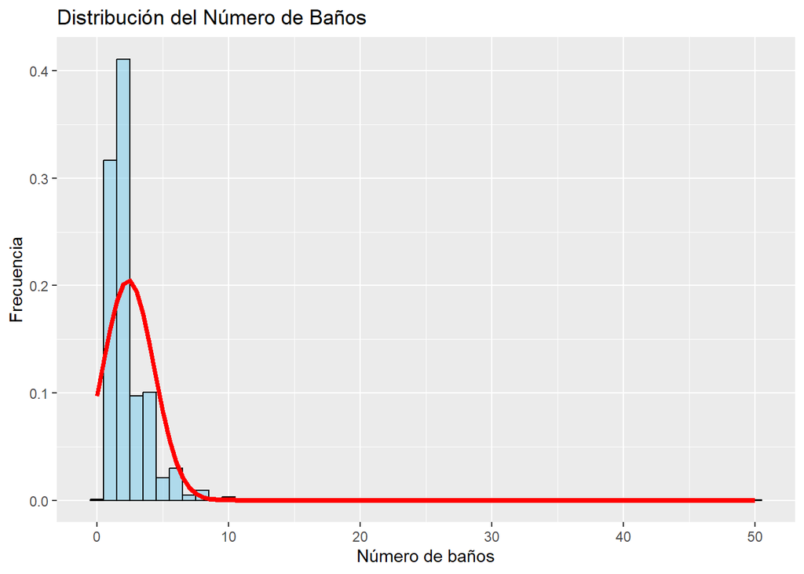

```r
datos1 <- NYHouse$BATH
ggplot(data.frame(x = datos1), aes(x = x)) +
  geom_histogram(binwidth = 1, fill = "skyblue", color = "black",
                 aes(y = ..density..), alpha = 0.6) +
  stat_function(fun = dnorm, args = list(mean = mean(datos1),
                                         sd = sd(datos1)), color = "red", size = 1.5) +
  labs(title = "Distribución del Número de Baños",
       x = "Número de baños",
       y = "Frecuencia")
```

Además de este histograma debemos realizar el resumen númerico a partir del cual podremos comprender los gráficos.

```r
NYHouse |> select(BATH) |> descr() |> kable(digits = 2)
```

|  | BATH |
| --- | --- |
| Mean | 2.37 |
| Std.Dev | 1.95 |
| Min | 0.00 |
| Q1 | 1.00 |
| Median | 2.00 |
| Q3 | 3.00 |
| Max | 50.00 |
| MAD | 1.48 |
| IQR | 2.00 |
| CV | 0.82 |
| Skewness | 7.76 |
| SE.Skewness | 0.04 |
| Kurtosis | 135.83 |
| N.Valid | 4801.00 |
| Pct.Valid | 100.00 |

Lo primero de todo es que en el histrograma podemos ver que la gran mayoría de valores están comprendidos entre 1 y 4 (incluyendo el valor de 2,373861), con un valor del 92,58% . También hay que destacar que los valores de esta variable están comprendidos entre en un rango amplio (0 y 50), es por eso que si observamos el resumen numérico podemos darnos cuenta que los valores extremos perturban algunos resultados aquí obtenidos, ya que no se tiene en cuenta que realmente la gran mayoría de casas no alcanzan un valor tan elevado. Por último, es claramente observable una asimetría positiva y una gran leptocurtosis.

### Estudio de la variable PROPERTYSQFT

```r
num_respuestas_PROPERTYSQFT <- length(unique(NYHouse$PROPERTYSQFT))
cat("La cantidad de respuestas obtenidas es:", num_respuestas_PROPERTYSQFT)
```

```
## La cantidad de respuestas obtenidas es: 1445
```

Como podemos observar, no tiene sentido realizar un estudio de esta variable. Una de las posibles soluciones sería discretizar la variable en percentiles (dividir en cien intervalos) para poder así realizar un estudio adecuado. Una vez discretizada la variable, realizamos un histograma con el siguiente código.

```r
intervalos2 <- seq(0, ceiling(max(NYHouse$PROPERTYSQFT) / 100000) * 100000, by = 330)
tabla_frecuencias_propertysqft <- NYHouse %>%
  count(PROPERTYSQFT) %>%
  mutate(f = n / nrow(NYHouse)) %>%
  mutate(N = cumsum(n),
         F = cumsum(f))
tabla_frecuencias_propertysqft <- tabla_frecuencias_propertysqft %>%
  mutate(Intervalo = cut(PROPERTYSQFT, breaks = intervalos2, right = FALSE)) %>%
  group_by(Intervalo) %>%
  summarise(n = sum(n),
            f = sum(f),
            N = sum(n),
            F = sum(f))
for (i in 2:nrow(tabla_frecuencias_propertysqft)) {
  tabla_frecuencias_propertysqft$N[i] <- tabla_frecuencias_propertysqft$N[i] + tabla_frecuencias_propertysqft$N[i - 1]
  tabla_frecuencias_propertysqft$F[i] <- tabla_frecuencias_propertysqft$F[i] + tabla_frecuencias_propertysqft$F[i - 1]
}
tabla_frecuencias_ordenada_propertysqft <- tabla_frecuencias_propertysqft %>%
  arrange(Intervalo)
print(tabla_frecuencias_ordenada_propertysqft)
```

```
## # A tibble: 59 × 5
##    Intervalo               n       f     N       F
##    <fct>               <int>   <dbl> <int>   <dbl>
##  1 [0,330)                12 0.00250    12 0.00250
##  2 [330,660)             223 0.0464    235 0.0489
##  3 [660,990)             606 0.126     841 0.175
##  4 [990,1.32e+03)        539 0.112    1380 0.287
##  5 [1.32e+03,1.65e+03)   355 0.0739   1735 0.361
##  6 [1.65e+03,1.98e+03)   312 0.0650   2047 0.426
##  7 [1.98e+03,2.31e+03)  1878 0.391    3925 0.818
##  8 [2.31e+03,2.64e+03)   155 0.0323   4080 0.850
##  9 [2.64e+03,2.97e+03)   120 0.0250   4200 0.875
## 10 [2.97e+03,3.3e+03)    111 0.0231   4311 0.898
## # ℹ 49 more rows
```

Procedemos a realizar el histograma completo:

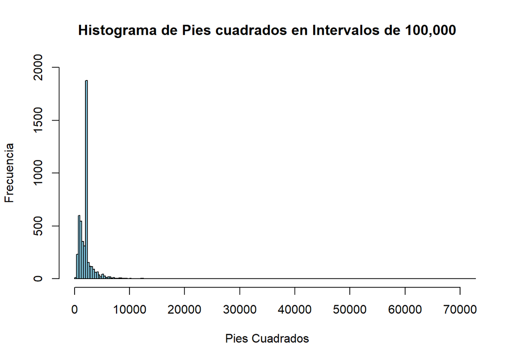

```r
intervalos2 <- seq(0, ceiling(max(NYHouse$PROPERTYSQFT) / 100000) * 100000, by = 330)
NYHouse$intervalo_propertysqft <- cut(NYHouse$PROPERTYSQFT, breaks = intervalos2, labels = FALSE)
frecuencia_por_intervalo2 <- table(NYHouse$intervalo_propertysqft)
hist(NYHouse$PROPERTYSQFT, breaks = intervalos2, xlab = "Pies Cuadrados", ylab = "Frecuencia", main = "Histograma de Pies cuadrados en Intervalos de 100,000", freq = TRUE, ylim = c(0, 2000), xlim = c(0, 70000), col = "skyblue", border = "black")
```

Como podemos observar, este histograma es ilegible. Los valores obtenidos estan concentrados mayoritariamente en un intervalo de 0 a 6000 donde se verá reflejado en la siguiente gráfica :

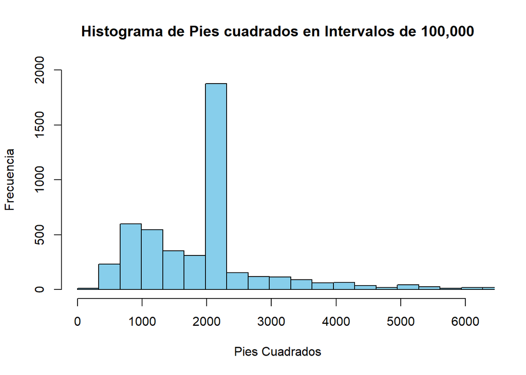

```r
intervalos2 <- seq(0, ceiling(max(NYHouse$PROPERTYSQFT) / 100000) * 100000, by = 330)
NYHouse$intervalo_propertysqft <- cut(NYHouse$PROPERTYSQFT, breaks = intervalos2, labels = FALSE)
frecuencia_por_intervalo2 <- table(NYHouse$intervalo_propertysqft)
hist(NYHouse$PROPERTYSQFT, breaks = intervalos2, xlab = "Pies Cuadrados", ylab = "Frecuencia", main = "Histograma de Pies cuadrados en Intervalos de 100,000", freq = TRUE, ylim = c(0, 2000), xlim = c(0, 6200), col = "skyblue", border = "black")
```

Además de este histograma debemos realizar el resumen númerico a partir del cual podremos comprender los gráficos.

```r
NYHouse |> select(PROPERTYSQFT) |> descr() |> kable(digits = 2)
```

|  | PROPERTYSQFT |
| --- | --- |
| Mean | 2184.21 |
| Std.Dev | 2377.14 |
| Min | 230.00 |
| Q1 | 1200.00 |
| Median | 2184.21 |
| Q3 | 2184.21 |
| Max | 65535.00 |
| MAD | 822.53 |
| IQR | 984.21 |
| CV | 1.09 |
| Skewness | 12.79 |
| SE.Skewness | 0.04 |
| Kurtosis | 258.18 |
| N.Valid | 4801.00 |
| Pct.Valid | 100.00 |

Al igual que hemos comentado anteriormente, lo primero que hay que destacar es que los valores de esta variable están comprendidos entre en un rango muy amplio (230 y 65535). Sin embargo, la gran mayoría, en torno al 97,48 %, se sitúan entre 0 y 6200. Por esta razón, hemos realizado un segundo histograma centrado en esos valores. En este segundo histrograma podemos ver que la gran mayoría de valores están comprendidos entre 1980 y 2300. Es por eso que si observamos el resumen numérico podemos darnos cuenta quelos valores extremos perturban algunos resultados aquí obtenidos, ya que no se tiene en cuenta que realmente la gran mayoría de casas no alcanzan un valor tan elevado. Por último, es claramente observable, en ambos histogramas, una asimetría positiva y una gran leptocurtosis.

### Estudio de la variable FORMATTED_ADDRESS

Aquí vamos a agrupar las variables ADDRESS, STATE, MAIN_ADDRESS, STREET_NAME y LONG_NAME en la misma variable llamada FORMATTED_ADDRESS ya que, en la variable FORMATTED_ADDRESS se incluyen el resto de las variables mencionadas con anterioridad.

```r
num_respuestas_FORMATTED_ADDRESS <- length(unique(NYHouse$FORMATTED_ADDRESS))
cat("La cantidad de respuestas obtenidas es:", num_respuestas_FORMATTED_ADDRESS)
```

```
## La cantidad de respuestas obtenidas es: 4550
```

En este caso tampoco tiene sentido realizar un estudio por intervalos ya que cada calle es independiente.

### Estudio de la variable ADMINISTRATIVE_AREA_LEVEL_2

```r
num_respuestas_ADMINISTRATIVE_AREA_LEVEL_2 <- length(unique(NYHouse$ADMINISTRATIVE_AREA_LEVEL_2))
cat("La cantidad de respuestas obtenidas es:", num_respuestas_ADMINISTRATIVE_AREA_LEVEL_2)
```

```
## La cantidad de respuestas obtenidas es: 29
```

En esta variable si podríamos realizar una tabla de frecuencias ordenada de mayor a menor. Para ello, vamos a realizar el estudio de las frecuencias con el siguiente código.

```r
tabla_frecuencias_administrative <- NYHouse |> count(ADMINISTRATIVE_AREA_LEVEL_2) |>
  mutate(f = n/nrow(NYHouse), N = cumsum(n),
         F = cumsum(f))
tabla_frecuencias_ordenada <-tabla_frecuencias_administrative[order(tabla_frecuencias_administrative[,2], decreasing = TRUE),]
print(tabla_frecuencias_ordenada)
```

```
##    ADMINISTRATIVE_AREA_LEVEL_2    n            f    N            F
## 29               United States 2484 0.5173922100 4801 1.0000000000
## 26                    New York 2241 0.4667777546 2290 0.4769839617
## 27             New York County   21 0.0043740887 2311 0.4813580504
## 15                       11214    8 0.0016663195   28 0.0058321183
## 25                Kings County    6 0.0012497396   49 0.0102062070
## 28               Queens County    6 0.0012497396 2317 0.4826077900
## 23                Bronx County    5 0.0010414497   42 0.0087481775
## 17                       11229    3 0.0006248698   32 0.0066652781
## 1                        10002    2 0.0004165799    2 0.0004165799
## 2                        10003    2 0.0004165799    4 0.0008331598
## 3                        10017    2 0.0004165799    6 0.0012497396
## 7                        10306    2 0.0004165799   11 0.0022911893
## 9                        10310    2 0.0004165799   14 0.0029160592
## 14                       10471    2 0.0004165799   20 0.0041657988
## 4                        10301    1 0.0002082899    7 0.0014580296
## 5                        10303    1 0.0002082899    8 0.0016663195
## 6                        10304    1 0.0002082899    9 0.0018746095
## 8                        10309    1 0.0002082899   12 0.0024994793
## 10                       10312    1 0.0002082899   15 0.0031243491
## 11                       10463    1 0.0002082899   16 0.0033326390
## 12                       10465    1 0.0002082899   17 0.0035409290
## 13                       10466    1 0.0002082899   18 0.0037492189
## 16                       11218    1 0.0002082899   29 0.0060404082
## 18                       11234    1 0.0002082899   33 0.0068735680
## 19                       11237    1 0.0002082899   34 0.0070818579
## 20                       11412    1 0.0002082899   35 0.0072901479
## 21                       11414    1 0.0002082899   36 0.0074984378
## 22                       11417    1 0.0002082899   37 0.0077067278
## 24                    Brooklyn    1 0.0002082899   43 0.0089564674
```

Observamos que la frecuencia máxima se divide en dos puntos por tanto, no es muy práctico crear una gráfica.

### Estudio de la variable LOCALITY

```r
num_respuestas_LOCALITY <- length(unique(NYHouse$LOCALITY))
cat("La cantidad de respuestas obtenidas es:", num_respuestas_LOCALITY)
```

```
## La cantidad de respuestas obtenidas es: 11
```

En esta variable si podríamos realizar una tabla de frecuencias ordenada de mayor a menor. Para ello, vamos a realizar el estudio de las frecuencias con el siguiente código.

```r
tabla_frecuencias_locality <- NYHouse |>
  count(LOCALITY) |>
  mutate(f = n / nrow(NYHouse), N = cumsum(n), F = cumsum(f))
tabla_frecuencias_ordenada2 <- tabla_frecuencias_locality |>
  arrange(desc(n))
tabla_frecuencias_ordenada2$F <- cumsum(tabla_frecuencias_ordenada2$f)
tabla_frecuencias_ordenada2$N <- cumsum(tabla_frecuencias_ordenada2$n)
print(tabla_frecuencias_ordenada2)
```

```
##           LOCALITY    n            f    N         F
## 1         New York 2505 0.5217662987 2505 0.5217663
## 2  New York County  979 0.2039158509 3484 0.7256821
## 3    Queens County  557 0.1160174964 4041 0.8416996
## 4     Kings County  464 0.0966465320 4505 0.9383462
## 5     Bronx County  182 0.0379087690 4687 0.9762549
## 6  Richmond County   59 0.0122891064 4746 0.9885441
## 7    United States   37 0.0077067278 4783 0.9962508
## 8         Brooklyn    6 0.0012497396 4789 0.9975005
## 9           Queens    6 0.0012497396 4795 0.9987503
## 10       The Bronx    5 0.0010414497 4800 0.9997917
## 11        Flatbush    1 0.0002082899 4801 1.0000000
```

A continuación, realizaremos una gráfica con las frecuencias relativas.

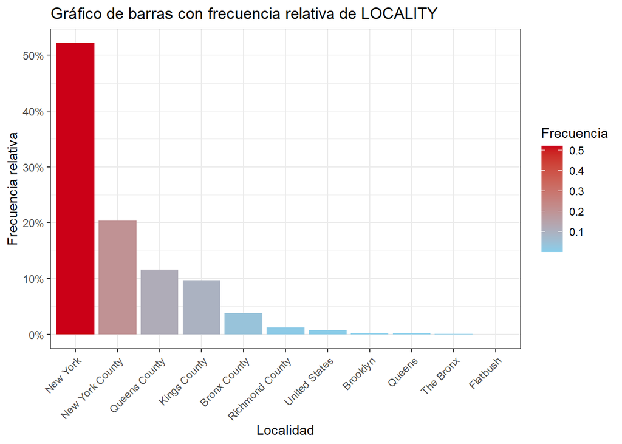

```r
NYHouse  |> group_by(LOCALITY) |>  summarise(Frequency = n()) |> mutate(Frequency = Frequency/sum(Frequency), LOCALITY = reorder(LOCALITY, -Frequency)) |> ggplot(aes(x = LOCALITY, y = Frequency)) + geom_bar(stat = "identity", aes(fill = Frequency)) + scale_y_continuous(labels = scales::percent) + theme_bw() + labs(title = "Gráfico de barras con frecuencia relativa de LOCALITY", x = "Localidad", y = "Frecuencia relativa") + scale_fill_gradient("Frecuencia", low = "skyblue", high = "#CB0017") + theme(axis.text.x = element_text(angle = 45, hjust = 1))
```

A continuación, podemos hacer un gráfico con las frecuencias absolutas haciendo uso del siguiente código.

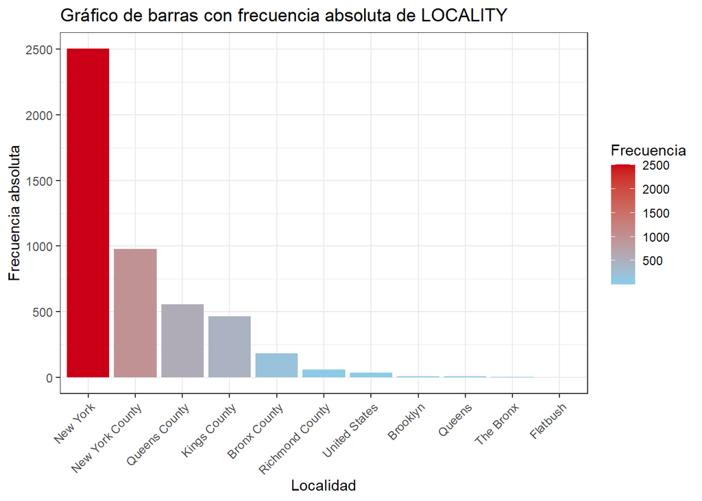

```r
NYHouse |>
  group_by(LOCALITY) |>
  summarise(Frequency = n()) |>
  mutate(LOCALITY = reorder(LOCALITY, -Frequency)) |>
  ggplot(aes(x = LOCALITY, y = Frequency)) +
  geom_bar(stat = "identity", aes(fill = Frequency)) +
  theme_bw() +
  labs(title = "Gráfico de barras con frecuencia absoluta de LOCALITY",
       x = "Localidad",
       y = "Frecuencia absoluta") +
  scale_fill_gradient("Frecuencia", low = "skyblue", high = "#CB0017") +
  theme(axis.text.x = element_text(angle = 45, hjust = 1))
```

Como podemos observar, más de la mitad de los casos ocurren en ‘’Nueva York’‘, ocupando un 52,17% y en términos numéricos representando 2505 de 4801 casos. Es más, para alcanzar la gran mayoría, llegando al 90% tenemos que tener en cuenta los tres siguientes valores:’‘New York County’‘,’‘Queens County’’ y ‘’Kings County’’. Con estos datos podemos encontrar de manera predominante la localidad en donde se venden más casas en Nueva York.

### Estudio de la variable SUBLOCALITY

```r
num_respuestas_SUBLOCALITY <- length(unique(NYHouse$SUBLOCALITY))
cat("La cantidad de respuestas obtenidas es:", num_respuestas_SUBLOCALITY)
```

```
## La cantidad de respuestas obtenidas es: 21
```

En esta variable si podríamos realizar una tabla de frecuencias ordenada de mayor a menor. Para ello, vamos a realizar el estudio de las frecuencias con el siguiente código.

```r
tabla_frecuencias_sublocality <- NYHouse |>
  count(SUBLOCALITY) |>
  mutate(f = n / nrow(NYHouse), N = cumsum(n), F = cumsum(f))
tabla_frecuencias_ordenada3 <- tabla_frecuencias_sublocality |>
  arrange(desc(n))
tabla_frecuencias_ordenada3$F <- cumsum(tabla_frecuencias_ordenada3$f)
tabla_frecuencias_ordenada3$N <- cumsum(tabla_frecuencias_ordenada3$n)
print(tabla_frecuencias_ordenada3)
```

```
##         SUBLOCALITY    n            f    N         F
## 1          New York 1016 0.2116225786 1016 0.2116226
## 2      Kings County  727 0.1514267861 1743 0.3630494
## 3     Queens County  684 0.1424703187 2427 0.5055197
## 4            Queens  555 0.1156009165 2982 0.6211206
## 5   Richmond County  480 0.0999791710 3462 0.7210998
## 6          Brooklyn  464 0.0966465320 3926 0.8177463
## 7      Bronx County  307 0.0639450115 4233 0.8816913
## 8   New York County  286 0.0595709227 4519 0.9412622
## 9         The Bronx  184 0.0383253489 4703 0.9795876
## 10    Staten Island   59 0.0122891064 4762 0.9918767
## 11        Manhattan   21 0.0043740887 4783 0.9962508
## 12         Flushing    4 0.0008331598 4787 0.9970839
## 13        Riverdale    4 0.0008331598 4791 0.9979171
## 14     Coney Island    3 0.0006248698 4794 0.9985420
## 15 Brooklyn Heights    1 0.0002082899 4795 0.9987503
## 16            Dumbo    1 0.0002082899 4796 0.9989586
## 17       East Bronx    1 0.0002082899 4797 0.9991668
## 18    Fort Hamilton    1 0.0002082899 4798 0.9993751
## 19  Jackson Heights    1 0.0002082899 4799 0.9995834
## 20        Rego Park    1 0.0002082899 4800 0.9997917
## 21    Snyder Avenue    1 0.0002082899 4801 1.0000000
```

A continuación, realizaremos una gráfica con las frecuencias relativas.

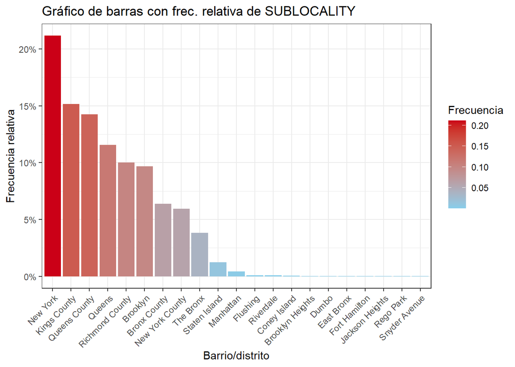

```r
NYHouse  |> group_by(SUBLOCALITY) |>  summarise(Frequency = n()) |> mutate(Frequency = Frequency/sum(Frequency), SUBLOCALITY = reorder(SUBLOCALITY, -Frequency)) |> ggplot(aes(x = SUBLOCALITY, y = Frequency)) + geom_bar(stat = "identity", aes(fill = Frequency)) + scale_y_continuous(labels = scales::percent) + theme_bw() + labs(title = "Gráfico de barras con frec. relativa de SUBLOCALITY", x = "Barrio/distrito", y = "Frecuencia relativa") + scale_fill_gradient("Frecuencia", low = "skyblue", high = "#CB0017") + theme(axis.text.x = element_text(angle = 45, hjust = 1))
```

A continuación, podemos hacer un gráfico con sus frecuencias absolutas con el siguiente código.

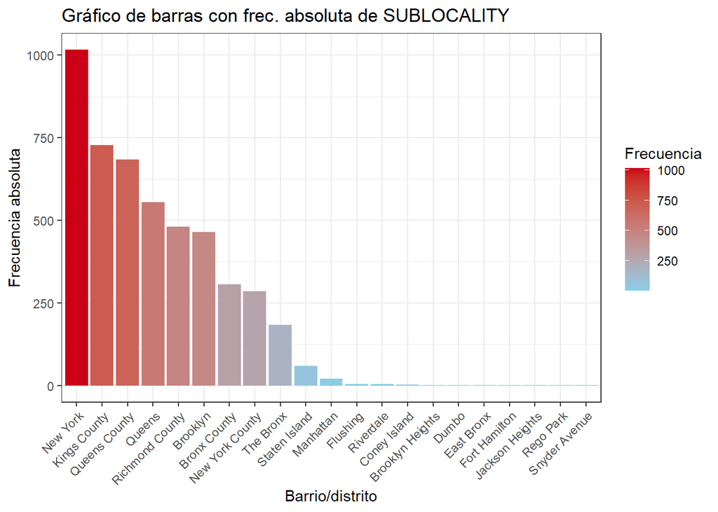

```r
NYHouse |>
  group_by(SUBLOCALITY) |>
  summarise(Frequency = n()) |>
  mutate(SUBLOCALITY = reorder(SUBLOCALITY, -Frequency)) |>
  ggplot(aes(x = SUBLOCALITY, y = Frequency)) +
  geom_bar(stat = "identity", aes(fill = Frequency)) +
  theme_bw() +
  labs(title = "Gráfico de barras con frec. absoluta de SUBLOCALITY",
       x = "Barrio/distrito",
       y = "Frecuencia absoluta") +
  scale_fill_gradient("Frecuencia", low = "skyblue", high = "#CB0017") +
  theme(axis.text.x = element_text(angle = 45, hjust = 1))
```

Como podemos observar en las gráficas, la distribución de casas según el barrio/distrito de Nueva York poseé una tendencia descendente pero mucho más uniforme, teniendo como referencia las anteriores representaciones. Cabe destacar que la mitad de los valores estudiados no representan prácticamente ni el 1% de la distribución expuesta. Siguiendo el gráfico, podemos llegar a la conclusión de que la mayoría de los habitantes suelen decantarse por los siguientes barrios/distritos: ‘’New York’‘, ’Kings County’‘,’‘Queens County’‘,’‘Queens’‘,’‘Richmond County’’ y ‘’Brooklyn’’ sumando entre ellos un 81,77% y en términos numéricos represenando 3926 casos de 4801.

## Análisis bivariante

En primer lugar realizaremos un estudio de correlación de todas las variables numéricas de nuestro dataset.

### Matriz de correlación numérica

```r
cor(NYHouse |> select(BEDS, BATH, PRICE, PROPERTYSQFT))
```

```
##                    BEDS       BATH      PRICE PROPERTYSQFT
## BEDS         1.00000000 0.77644740 0.05218913    0.4205033
## BATH         0.77644740 1.00000000 0.07937058    0.4839351
## PRICE        0.05218913 0.07937058 1.00000000    0.1108888
## PROPERTYSQFT 0.42050326 0.48393507 0.11088877    1.0000000
```

Para una mayor comprensión, realizaremos un gráfico con los datos ya mostrados.

### Gráfico de correlación numérica

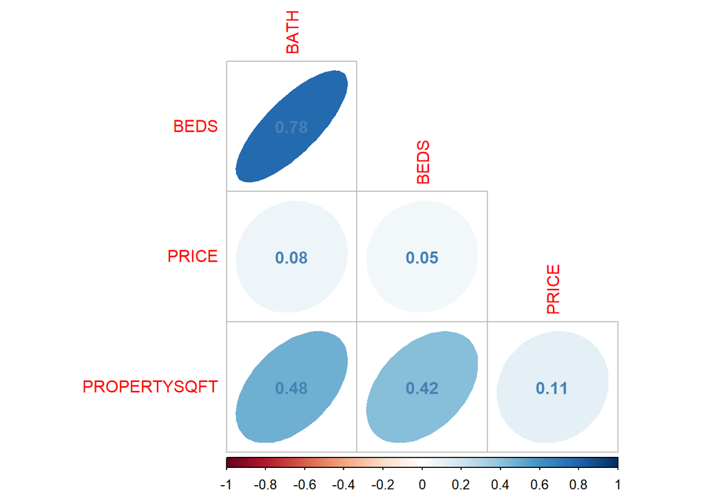

```r
NYHouse |> select(BATH, BEDS, PRICE, PROPERTYSQFT) |>
  cor() |>
  corrplot(method = "ellipse",  # Usa elipses para representar correlaciones
           type = "lower",  # Muestra solo la mitad inferior de la matriz
           addCoef.col = "steelblue",  # Color de los coeficientes de correlación
           diag = FALSE)  # Omite la diagonal principal
```

Aunque el principal objetivo de este estudio era comparar el precio de las casas con el tamaño (pies cuadrados), como podemos comprobar su correlación lineal es casi nula (0,11). Pero aun así, realizaremos un estudio por si estamos ante una distribución no lineal (posible relación polinómica).

Además, realizaremos un estudio de las variables BEDS y BATHS, que son las que han obtenido un mayor valor en el análisis de correlación lineal. El resto de posibles estudios, quedan descartados dado su nula importancia y su baja correlación lineal.

### Estudio de la variable BEDS Y BATH

Para comenzar con este estudio realizaremos lo primero de todo las tablas de contingencia tanto relativas como absolutas.

#### Tabla de contingencia entre BEDS Y BATH ABSOLUTA

```r
kable(table(NYHouse$BEDS, NYHouse$BATH))
```

|  | 0 | 1 | 2 | 2.37386085796844 | 3 | 4 | 5 | 6 | 7 | 8 | 9 | 10 | 11 | 12 | 13 | 16 | 17 | 20 | 24 | 32 | 43 | 50 |
| --- | --- | --- | --- | --- | --- | --- | --- | --- | --- | --- | --- | --- | --- | --- | --- | --- | --- | --- | --- | --- | --- | --- |
| 1 | 0 | 741 | 72 | 7 | 0 | 0 | 0 | 0 | 0 | 0 | 0 | 0 | 0 | 0 | 0 | 0 | 0 | 0 | 0 | 0 | 0 | 0 |
| 2 | 0 | 423 | 551 | 2 | 17 | 2 | 0 | 0 | 0 | 0 | 0 | 0 | 0 | 0 | 0 | 0 | 0 | 0 | 0 | 0 | 0 | 0 |
| 3 | 3 | 338 | 667 | 171 | 143 | 113 | 6 | 7 | 2 | 5 | 0 | 0 | 0 | 0 | 0 | 0 | 0 | 0 | 0 | 1 | 0 | 0 |
| 4 | 0 | 15 | 243 | 30 | 108 | 156 | 7 | 11 | 0 | 0 | 0 | 0 | 0 | 0 | 0 | 0 | 0 | 0 | 0 | 0 | 0 | 0 |
| 5 | 0 | 3 | 85 | 38 | 89 | 98 | 14 | 28 | 5 | 0 | 0 | 0 | 0 | 0 | 0 | 0 | 0 | 0 | 0 | 0 | 0 | 0 |
| 6 | 0 | 0 | 39 | 28 | 63 | 61 | 40 | 31 | 2 | 6 | 0 | 0 | 0 | 0 | 0 | 0 | 1 | 0 | 0 | 0 | 0 | 0 |
| 7 | 0 | 0 | 12 | 11 | 16 | 26 | 11 | 16 | 2 | 8 | 1 | 2 | 0 | 0 | 0 | 0 | 0 | 0 | 0 | 0 | 0 | 0 |
| 8 | 0 | 0 | 2 | 9 | 18 | 16 | 13 | 11 | 3 | 7 | 1 | 3 | 0 | 0 | 0 | 1 | 0 | 0 | 0 | 0 | 0 | 0 |
| 9 | 0 | 0 | 0 | 3 | 11 | 5 | 5 | 9 | 2 | 3 | 0 | 0 | 1 | 0 | 0 | 0 | 0 | 0 | 0 | 0 | 0 | 0 |
| 10 | 0 | 0 | 0 | 1 | 0 | 2 | 2 | 3 | 1 | 3 | 1 | 7 | 0 | 0 | 1 | 0 | 0 | 0 | 0 | 0 | 0 | 0 |
| 11 | 0 | 1 | 0 | 0 | 1 | 1 | 1 | 12 | 0 | 1 | 1 | 1 | 1 | 0 | 0 | 0 | 0 | 0 | 0 | 0 | 0 | 0 |
| 12 | 0 | 0 | 0 | 2 | 1 | 3 | 0 | 10 | 2 | 4 | 0 | 1 | 0 | 0 | 0 | 0 | 0 | 0 | 0 | 0 | 0 | 0 |
| 13 | 0 | 0 | 0 | 0 | 0 | 1 | 1 | 0 | 2 | 1 | 0 | 0 | 0 | 0 | 0 | 0 | 0 | 0 | 0 | 0 | 0 | 0 |
| 14 | 0 | 0 | 0 | 0 | 0 | 0 | 0 | 3 | 2 | 1 | 1 | 0 | 0 | 0 | 0 | 0 | 0 | 0 | 0 | 0 | 0 | 0 |
| 15 | 0 | 0 | 0 | 0 | 0 | 0 | 0 | 1 | 1 | 0 | 2 | 1 | 0 | 0 | 0 | 0 | 0 | 0 | 0 | 0 | 0 | 0 |
| 16 | 0 | 0 | 0 | 0 | 0 | 0 | 0 | 0 | 0 | 3 | 0 | 0 | 0 | 0 | 0 | 1 | 0 | 0 | 0 | 0 | 0 | 0 |
| 18 | 0 | 0 | 0 | 0 | 0 | 0 | 0 | 0 | 0 | 0 | 0 | 0 | 0 | 1 | 0 | 0 | 0 | 0 | 0 | 0 | 0 | 0 |
| 19 | 0 | 0 | 0 | 0 | 0 | 0 | 0 | 0 | 0 | 1 | 0 | 0 | 0 | 0 | 0 | 0 | 0 | 0 | 0 | 0 | 0 | 0 |
| 20 | 0 | 0 | 0 | 0 | 0 | 0 | 0 | 0 | 0 | 1 | 0 | 1 | 0 | 0 | 0 | 0 | 0 | 1 | 0 | 0 | 0 | 0 |
| 24 | 0 | 0 | 0 | 0 | 0 | 0 | 0 | 0 | 0 | 1 | 0 | 0 | 0 | 0 | 0 | 1 | 0 | 0 | 1 | 0 | 0 | 0 |
| 30 | 0 | 0 | 0 | 0 | 0 | 0 | 0 | 0 | 0 | 0 | 0 | 0 | 0 | 0 | 0 | 0 | 0 | 1 | 0 | 0 | 0 | 0 |
| 32 | 0 | 0 | 0 | 0 | 0 | 0 | 0 | 0 | 0 | 0 | 0 | 0 | 0 | 2 | 0 | 0 | 0 | 0 | 0 | 0 | 0 | 0 |
| 35 | 0 | 0 | 0 | 0 | 0 | 0 | 0 | 0 | 0 | 0 | 0 | 0 | 0 | 0 | 0 | 1 | 0 | 0 | 0 | 0 | 0 | 0 |
| 36 | 0 | 0 | 0 | 0 | 0 | 0 | 0 | 0 | 0 | 0 | 0 | 0 | 0 | 0 | 0 | 1 | 0 | 0 | 0 | 0 | 0 | 0 |
| 40 | 0 | 0 | 0 | 0 | 0 | 0 | 0 | 0 | 0 | 0 | 0 | 0 | 0 | 0 | 0 | 0 | 0 | 1 | 0 | 0 | 0 | 0 |
| 42 | 0 | 0 | 0 | 0 | 0 | 0 | 0 | 0 | 0 | 0 | 0 | 0 | 0 | 0 | 0 | 0 | 0 | 0 | 0 | 0 | 1 | 0 |
| 50 | 0 | 0 | 0 | 0 | 0 | 0 | 0 | 0 | 0 | 0 | 0 | 0 | 0 | 0 | 0 | 0 | 0 | 0 | 0 | 0 | 0 | 1 |

#### Tabla de contingencia entre BEDS y BATH RELATIVA

```r
kable(prop.table(table(NYHouse$BEDS, NYHouse$BATH)), digits = 6)
```

|  | 0 | 1 | 2 | 2.37386085796844 | 3 | 4 | 5 | 6 | 7 | 8 | 9 | 10 | 11 | 12 | 13 | 16 | 17 | 20 | 24 | 32 | 43 | 50 |
| --- | --- | --- | --- | --- | --- | --- | --- | --- | --- | --- | --- | --- | --- | --- | --- | --- | --- | --- | --- | --- | --- | --- |
| 1 | 0.000000 | 0.154343 | 0.014997 | 0.001458 | 0.000000 | 0.000000 | 0.000000 | 0.000000 | 0.000000 | 0.000000 | 0.000000 | 0.000000 | 0.000000 | 0.000000 | 0.000000 | 0.000000 | 0.000000 | 0.000000 | 0.000000 | 0.000000 | 0.000000 | 0.000000 |
| 2 | 0.000000 | 0.088107 | 0.114768 | 0.000417 | 0.003541 | 0.000417 | 0.000000 | 0.000000 | 0.000000 | 0.000000 | 0.000000 | 0.000000 | 0.000000 | 0.000000 | 0.000000 | 0.000000 | 0.000000 | 0.000000 | 0.000000 | 0.000000 | 0.000000 | 0.000000 |
| 3 | 0.000625 | 0.070402 | 0.138929 | 0.035618 | 0.029785 | 0.023537 | 0.001250 | 0.001458 | 0.000417 | 0.001041 | 0.000000 | 0.000000 | 0.000000 | 0.000000 | 0.000000 | 0.000000 | 0.000000 | 0.000000 | 0.000000 | 0.000208 | 0.000000 | 0.000000 |
| 4 | 0.000000 | 0.003124 | 0.050614 | 0.006249 | 0.022495 | 0.032493 | 0.001458 | 0.002291 | 0.000000 | 0.000000 | 0.000000 | 0.000000 | 0.000000 | 0.000000 | 0.000000 | 0.000000 | 0.000000 | 0.000000 | 0.000000 | 0.000000 | 0.000000 | 0.000000 |
| 5 | 0.000000 | 0.000625 | 0.017705 | 0.007915 | 0.018538 | 0.020412 | 0.002916 | 0.005832 | 0.001041 | 0.000000 | 0.000000 | 0.000000 | 0.000000 | 0.000000 | 0.000000 | 0.000000 | 0.000000 | 0.000000 | 0.000000 | 0.000000 | 0.000000 | 0.000000 |
| 6 | 0.000000 | 0.000000 | 0.008123 | 0.005832 | 0.013122 | 0.012706 | 0.008332 | 0.006457 | 0.000417 | 0.001250 | 0.000000 | 0.000000 | 0.000000 | 0.000000 | 0.000000 | 0.000000 | 0.000208 | 0.000000 | 0.000000 | 0.000000 | 0.000000 | 0.000000 |
| 7 | 0.000000 | 0.000000 | 0.002499 | 0.002291 | 0.003333 | 0.005416 | 0.002291 | 0.003333 | 0.000417 | 0.001666 | 0.000208 | 0.000417 | 0.000000 | 0.000000 | 0.000000 | 0.000000 | 0.000000 | 0.000000 | 0.000000 | 0.000000 | 0.000000 | 0.000000 |
| 8 | 0.000000 | 0.000000 | 0.000417 | 0.001875 | 0.003749 | 0.003333 | 0.002708 | 0.002291 | 0.000625 | 0.001458 | 0.000208 | 0.000625 | 0.000000 | 0.000000 | 0.000000 | 0.000208 | 0.000000 | 0.000000 | 0.000000 | 0.000000 | 0.000000 | 0.000000 |
| 9 | 0.000000 | 0.000000 | 0.000000 | 0.000625 | 0.002291 | 0.001041 | 0.001041 | 0.001875 | 0.000417 | 0.000625 | 0.000000 | 0.000000 | 0.000208 | 0.000000 | 0.000000 | 0.000000 | 0.000000 | 0.000000 | 0.000000 | 0.000000 | 0.000000 | 0.000000 |
| 10 | 0.000000 | 0.000000 | 0.000000 | 0.000208 | 0.000000 | 0.000417 | 0.000417 | 0.000625 | 0.000208 | 0.000625 | 0.000208 | 0.001458 | 0.000000 | 0.000000 | 0.000208 | 0.000000 | 0.000000 | 0.000000 | 0.000000 | 0.000000 | 0.000000 | 0.000000 |
| 11 | 0.000000 | 0.000208 | 0.000000 | 0.000000 | 0.000208 | 0.000208 | 0.000208 | 0.002499 | 0.000000 | 0.000208 | 0.000208 | 0.000208 | 0.000208 | 0.000000 | 0.000000 | 0.000000 | 0.000000 | 0.000000 | 0.000000 | 0.000000 | 0.000000 | 0.000000 |
| 12 | 0.000000 | 0.000000 | 0.000000 | 0.000417 | 0.000208 | 0.000625 | 0.000000 | 0.002083 | 0.000417 | 0.000833 | 0.000000 | 0.000208 | 0.000000 | 0.000000 | 0.000000 | 0.000000 | 0.000000 | 0.000000 | 0.000000 | 0.000000 | 0.000000 | 0.000000 |
| 13 | 0.000000 | 0.000000 | 0.000000 | 0.000000 | 0.000000 | 0.000208 | 0.000208 | 0.000000 | 0.000417 | 0.000208 | 0.000000 | 0.000000 | 0.000000 | 0.000000 | 0.000000 | 0.000000 | 0.000000 | 0.000000 | 0.000000 | 0.000000 | 0.000000 | 0.000000 |
| 14 | 0.000000 | 0.000000 | 0.000000 | 0.000000 | 0.000000 | 0.000000 | 0.000000 | 0.000625 | 0.000417 | 0.000208 | 0.000208 | 0.000000 | 0.000000 | 0.000000 | 0.000000 | 0.000000 | 0.000000 | 0.000000 | 0.000000 | 0.000000 | 0.000000 | 0.000000 |
| 15 | 0.000000 | 0.000000 | 0.000000 | 0.000000 | 0.000000 | 0.000000 | 0.000000 | 0.000208 | 0.000208 | 0.000000 | 0.000417 | 0.000208 | 0.000000 | 0.000000 | 0.000000 | 0.000000 | 0.000000 | 0.000000 | 0.000000 | 0.000000 | 0.000000 | 0.000000 |
| 16 | 0.000000 | 0.000000 | 0.000000 | 0.000000 | 0.000000 | 0.000000 | 0.000000 | 0.000000 | 0.000000 | 0.000625 | 0.000000 | 0.000000 | 0.000000 | 0.000000 | 0.000000 | 0.000208 | 0.000000 | 0.000000 | 0.000000 | 0.000000 | 0.000000 | 0.000000 |
| 18 | 0.000000 | 0.000000 | 0.000000 | 0.000000 | 0.000000 | 0.000000 | 0.000000 | 0.000000 | 0.000000 | 0.000000 | 0.000000 | 0.000000 | 0.000000 | 0.000208 | 0.000000 | 0.000000 | 0.000000 | 0.000000 | 0.000000 | 0.000000 | 0.000000 | 0.000000 |
| 19 | 0.000000 | 0.000000 | 0.000000 | 0.000000 | 0.000000 | 0.000000 | 0.000000 | 0.000000 | 0.000000 | 0.000208 | 0.000000 | 0.000000 | 0.000000 | 0.000000 | 0.000000 | 0.000000 | 0.000000 | 0.000000 | 0.000000 | 0.000000 | 0.000000 | 0.000000 |
| 20 | 0.000000 | 0.000000 | 0.000000 | 0.000000 | 0.000000 | 0.000000 | 0.000000 | 0.000000 | 0.000000 | 0.000208 | 0.000000 | 0.000208 | 0.000000 | 0.000000 | 0.000000 | 0.000000 | 0.000000 | 0.000208 | 0.000000 | 0.000000 | 0.000000 | 0.000000 |
| 24 | 0.000000 | 0.000000 | 0.000000 | 0.000000 | 0.000000 | 0.000000 | 0.000000 | 0.000000 | 0.000000 | 0.000208 | 0.000000 | 0.000000 | 0.000000 | 0.000000 | 0.000000 | 0.000208 | 0.000000 | 0.000000 | 0.000208 | 0.000000 | 0.000000 | 0.000000 |
| 30 | 0.000000 | 0.000000 | 0.000000 | 0.000000 | 0.000000 | 0.000000 | 0.000000 | 0.000000 | 0.000000 | 0.000000 | 0.000000 | 0.000000 | 0.000000 | 0.000000 | 0.000000 | 0.000000 | 0.000000 | 0.000208 | 0.000000 | 0.000000 | 0.000000 | 0.000000 |
| 32 | 0.000000 | 0.000000 | 0.000000 | 0.000000 | 0.000000 | 0.000000 | 0.000000 | 0.000000 | 0.000000 | 0.000000 | 0.000000 | 0.000000 | 0.000000 | 0.000417 | 0.000000 | 0.000000 | 0.000000 | 0.000000 | 0.000000 | 0.000000 | 0.000000 | 0.000000 |
| 35 | 0.000000 | 0.000000 | 0.000000 | 0.000000 | 0.000000 | 0.000000 | 0.000000 | 0.000000 | 0.000000 | 0.000000 | 0.000000 | 0.000000 | 0.000000 | 0.000000 | 0.000000 | 0.000208 | 0.000000 | 0.000000 | 0.000000 | 0.000000 | 0.000000 | 0.000000 |
| 36 | 0.000000 | 0.000000 | 0.000000 | 0.000000 | 0.000000 | 0.000000 | 0.000000 | 0.000000 | 0.000000 | 0.000000 | 0.000000 | 0.000000 | 0.000000 | 0.000000 | 0.000000 | 0.000208 | 0.000000 | 0.000000 | 0.000000 | 0.000000 | 0.000000 | 0.000000 |
| 40 | 0.000000 | 0.000000 | 0.000000 | 0.000000 | 0.000000 | 0.000000 | 0.000000 | 0.000000 | 0.000000 | 0.000000 | 0.000000 | 0.000000 | 0.000000 | 0.000000 | 0.000000 | 0.000000 | 0.000000 | 0.000208 | 0.000000 | 0.000000 | 0.000000 | 0.000000 |
| 42 | 0.000000 | 0.000000 | 0.000000 | 0.000000 | 0.000000 | 0.000000 | 0.000000 | 0.000000 | 0.000000 | 0.000000 | 0.000000 | 0.000000 | 0.000000 | 0.000000 | 0.000000 | 0.000000 | 0.000000 | 0.000000 | 0.000000 | 0.000000 | 0.000208 | 0.000000 |
| 50 | 0.000000 | 0.000000 | 0.000000 | 0.000000 | 0.000000 | 0.000000 | 0.000000 | 0.000000 | 0.000000 | 0.000000 | 0.000000 | 0.000000 | 0.000000 | 0.000000 | 0.000000 | 0.000000 | 0.000000 | 0.000000 | 0.000000 | 0.000000 | 0.000000 | 0.000208 |

A continución realizaremos dos gráficas de dispersión, donde, en la primera haremos el ajuste de regresión más adecuado posible (mediante la función geom_smooth); y en la segunda, continuando el estudio de correlación, elaboraremos un ajuste de regresión lineal.

#### Gráfico de dispersión con ajuste de regresión de BATHS y BEDS

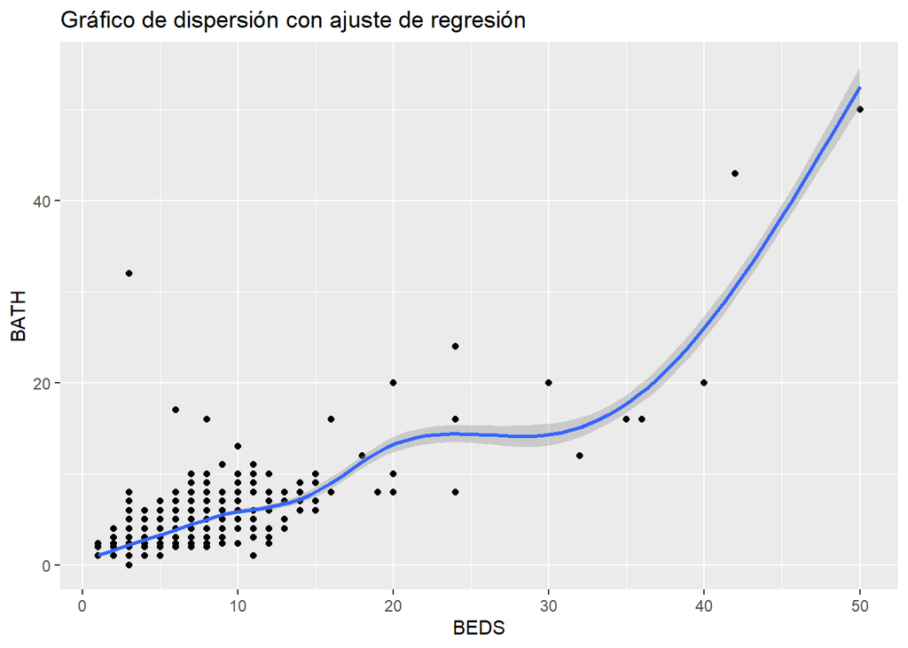

```r
NYHouse |>
  ggplot(aes(x = BEDS, y = BATH)) +
  geom_point() +
  geom_smooth() +
  labs(title = "Gráfico de dispersión con ajuste de regresión")
```

#### Gráfico de dispersión con ajuste de regresión lineal de BATHS y BEDS

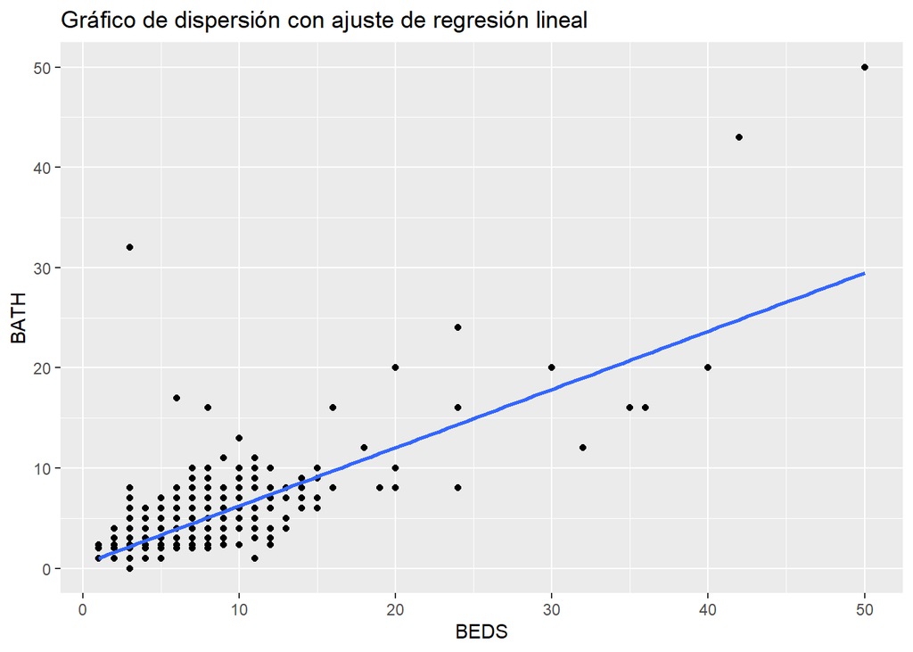

```r
NYHouse |>
  ggplot(aes(x = BEDS, y = BATH)) +
  geom_point() +
  geom_smooth(method = lm, se = FALSE) +
  labs(title = "Gráfico de dispersión con ajuste de regresión lineal")
```

Además de este gráfico de dispersión con regresón lineal debemos realizar los siguientes cálculos, que nos proporcionarán información de gran utilidad para su posterior interpretación.

```r
lineal_1 <- NYHouse |>
  select(BEDS, BATH) |>
  with(lm(BEDS ~ BATH))
summary(lineal_1)
```

```
##
## Call:
## lm(formula = BEDS ~ BATH)
##
## Residuals:
##      Min       1Q   Median       3Q      Max
## -31.1029  -0.9688  -0.0066   0.9556  18.6532
##
## Coefficients:
##             Estimate Std. Error t value Pr(>|t|)
## (Intercept)  0.89320    0.03733   23.93   <2e-16 ***
## BATH         1.03780    0.01216   85.35   <2e-16 ***
## ---
## Signif. codes:  0 '***' 0.001 '**' 0.01 '*' 0.05 '.' 0.1 ' ' 1
##
## Residual standard error: 1.64 on 4799 degrees of freedom
## Multiple R-squared:  0.6029, Adjusted R-squared:  0.6028
## F-statistic:  7285 on 1 and 4799 DF,  p-value: < 2.2e-16
```

Comenzando con la interpretación de la regresión lineal, si observamos la gráfica podemos darnos cuenta de que ésta y el valor obtenido en el estudio de correlación numérica son coherentes entre sí. Esto se debe a que, como podemos ver la gráfica posee una correcta regresión lineal, pero algunos datos erróneos provocan un descenso en el coeficiente de correlación lineal (el número sería elevado pero no demasiado).

Hablando de datos erróneos, o también llamados en este caso residuos, estos son una minoría en comparación con la gran mayoría de valores presentes en la representación. Además que su valor es en gran parte de las ocasiones pequeño.

Por último y para concluir con el estudio de esta regresión lineal, pasaremos a ver la proporción de variabilidad. La variable BEDS explica el 60,29% de la variabilidad de BATH. Por lo tanto, el valor obtenido podríamos decir que es moderadamente fiable por ser relativamente alto y fuerte.

A continuación, realizaremos dos gráficos complementarios a los ya vistos y analizados.

#### Gráfico de dispersión con número de BATH, BEDS y LOCALITY

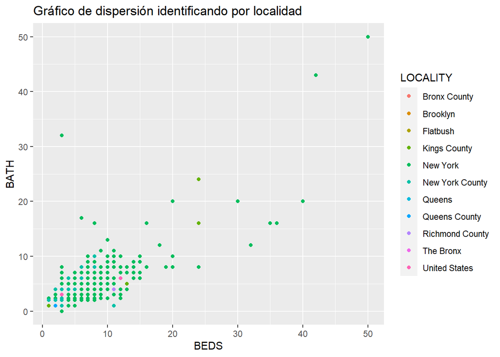

```r
NYHouse |>
  ggplot(aes(x = BEDS, y = BATH, col = LOCALITY)) +
  geom_point() +
  labs(title = "Gráfico de dispersión identificando por localidad ")
```

#### Gráfico de dispersión con número de BATH, BEDS y SUBLOCALITY

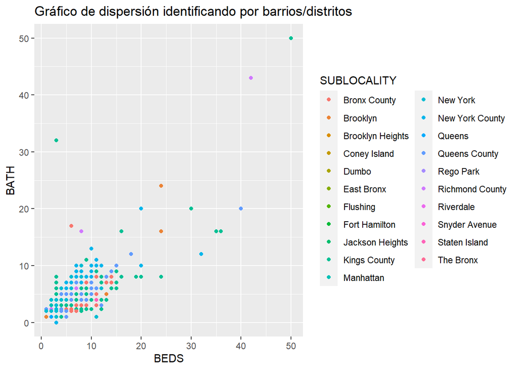

```r
NYHouse |>
  ggplot(aes(x = BEDS, y = BATH, col = SUBLOCALITY)) +
  geom_point() +
  labs(title = "Gráfico de dispersión identificando por barrios/distritos")
```

Estas dos últimas gráficas enriquecen el estudio de estas dos variables, pero tienen un gran problema. Nuestro conjunto de datos nos ofrece 4801 valores, y estas dos variables son discretas. Por lo tanto, esta característica limita la comprensión al comparar con un tercera variable. En otras palabras, tenemos muchos datos solapados.

De todos modos, con ambas gráficas podemos hacernos una idea de la cantidad de habitaciones y baños que suelen tener cada localidad y barrio/distrito.

### Estudio de la variable PRICE Y PROPRTYSQFT

#### Tabla de contingencia entre PRICE Y PROPRTYSQFT ABSOLUTA

```r
histo <- hist(NYHouse$PROPERTYSQFT, plot = FALSE, breaks = 50)
histo2 <- hist(NYHouse$PRICE, plot = FALSE, breaks = 99)
NYHouse <- NYHouse |>
  mutate(clase_propertysqft = cut(PROPERTYSQFT, breaks = histo$breaks)) |>
  mutate(clase_price = cut(PRICE, breaks = histo2$breaks))
tabla <- table(NYHouse$clase_propertysqft, NYHouse$clase_price) |> addmargins()
tabla |> kable()
```

|  | (0,2e+07] | (2e+07,4e+07] | (4e+07,6e+07] | (6e+07,8e+07] | (8e+07,1e+08] | (1e+08,1.2e+08] | (1.2e+08,1.4e+08] | (1.4e+08,1.6e+08] | (1.6e+08,1.8e+08] | (1.8e+08,2e+08] | (2e+08,2.2e+08] | (2.2e+08,2.4e+08] | (2.4e+08,2.6e+08] | (2.6e+08,2.8e+08] | (2.8e+08,3e+08] | (3e+08,3.2e+08] | (3.2e+08,3.4e+08] | (3.4e+08,3.6e+08] | (3.6e+08,3.8e+08] | (3.8e+08,4e+08] | (4e+08,4.2e+08] | (4.2e+08,4.4e+08] | (4.4e+08,4.6e+08] | (4.6e+08,4.8e+08] | (4.8e+08,5e+08] | (5e+08,5.2e+08] | (5.2e+08,5.4e+08] | (5.4e+08,5.6e+08] | (5.6e+08,5.8e+08] | … |
| --- | --- | --- | --- | --- | --- | --- | --- | --- | --- | --- | --- | --- | --- | --- | --- | --- | --- | --- | --- | --- | --- | --- | --- | --- | --- | --- | --- | --- | --- | --- |
| (0,1e+03] | 891 | 0 | 0 | 0 | 0 | 0 | 0 | 0 | 0 | 0 | 0 | 0 | 0 | 0 | 0 | 0 | 0 | 0 | 0 | 0 | 0 | 0 | 0 | 0 | 0 | 0 | 0 | 0 | 0 | … |
| (1e+03,2e+03] | 1202 | 0 | 0 | 0 | 0 | 0 | 0 | 0 | 0 | 0 | 0 | 0 | 0 | 0 | 0 | 0 | 0 | 0 | 0 | 0 | 0 | 0 | 0 | 0 | 0 | 0 | 0 | 0 | 0 | … |
| (2e+03,3e+03] | 2112 | 12 | 4 | 0 | 0 | 0 | 0 | 0 | 0 | 0 | 0 | 0 | 0 | 0 | 0 | 0 | 0 | 0 | 0 | 0 | 0 | 0 | 0 | 0 | 0 | 0 | 0 | 0 | 0 | … |
| (3e+03,4e+03] | 259 | 1 | 0 | 0 | 0 | 0 | 0 | 0 | 0 | 0 | 0 | 0 | 0 | 0 | 0 | 0 | 0 | 0 | 0 | 0 | 0 | 0 | 0 | 0 | 0 | 0 | 0 | 0 | 0 | … |
| (4e+03,5e+03] | 111 | 6 | 0 | 0 | 0 | 0 | 0 | 0 | 0 | 0 | 0 | 0 | 0 | 0 | 0 | 0 | 0 | 0 | 0 | 0 | 0 | 0 | 0 | 0 | 0 | 0 | 0 | 0 | 0 | … |
| (5e+03,6e+03] | 74 | 3 | 0 | 0 | 0 | 0 | 0 | 0 | 0 | 0 | 0 | 0 | 0 | 0 | 0 | 0 | 0 | 0 | 0 | 0 | 0 | 0 | 0 | 0 | 0 | 0 | 0 | 0 | 0 | … |
| (6e+03,7e+03] | 32 | 0 | 1 | 0 | 0 | 0 | 0 | 0 | 0 | 0 | 0 | 0 | 0 | 0 | 0 | 0 | 0 | 0 | 0 | 0 | 0 | 0 | 0 | 0 | 0 | 0 | 0 | 0 | 0 | … |
| (7e+03,8e+03] | 19 | 5 | 0 | 0 | 0 | 0 | 0 | 0 | 0 | 0 | 0 | 0 | 0 | 0 | 0 | 0 | 0 | 0 | 0 | 0 | 0 | 0 | 0 | 0 | 0 | 0 | 0 | 0 | 0 | … |
| (8e+03,9e+03] | 13 | 6 | 0 | 0 | 0 | 0 | 0 | 0 | 0 | 0 | 0 | 0 | 0 | 0 | 0 | 0 | 0 | 0 | 0 | 0 | 0 | 0 | 0 | 0 | 0 | 0 | 0 | 0 | 0 | … |
| (9e+03,1e+04] | 6 | 1 | 0 | 0 | 0 | 0 | 0 | 0 | 0 | 0 | 0 | 0 | 0 | 0 | 0 | 0 | 0 | 0 | 0 | 0 | 0 | 0 | 0 | 0 | 0 | 0 | 0 | 0 | 0 | … |
| (1e+04,1.1e+04] | 3 | 2 | 0 | 0 | 0 | 0 | 0 | 0 | 0 | 0 | 0 | 0 | 0 | 0 | 0 | 0 | 0 | 0 | 0 | 0 | 0 | 0 | 0 | 0 | 0 | 0 | 0 | 0 | 0 | … |
| (1.1e+04,1.2e+04] | 4 | 3 | 1 | 0 | 0 | 0 | 0 | 0 | 0 | 0 | 0 | 0 | 0 | 0 | 0 | 0 | 0 | 0 | 0 | 0 | 0 | 0 | 0 | 0 | 0 | 0 | 0 | 0 | 0 | … |
| (1.2e+04,1.3e+04] | 6 | 1 | 0 | 0 | 0 | 0 | 0 | 0 | 0 | 0 | 0 | 0 | 0 | 0 | 0 | 0 | 0 | 0 | 0 | 0 | 0 | 0 | 0 | 0 | 0 | 0 | 0 | 0 | 0 | … |
| (1.3e+04,1.4e+04] | 0 | 0 | 0 | 0 | 0 | 0 | 0 | 0 | 0 | 0 | 0 | 0 | 0 | 0 | 0 | 0 | 0 | 0 | 0 | 0 | 0 | 0 | 0 | 0 | 0 | 0 | 0 | 0 | 0 | … |
| (1.4e+04,1.5e+04] | 1 | 0 | 1 | 0 | 0 | 0 | 0 | 0 | 0 | 0 | 0 | 0 | 0 | 0 | 0 | 0 | 0 | 0 | 0 | 0 | 0 | 0 | 0 | 0 | 0 | 0 | 0 | 0 | 0 | … |
| (1.5e+04,1.6e+04] | 1 | 1 | 0 | 1 | 0 | 0 | 0 | 0 | 0 | 0 | 0 | 0 | 0 | 0 | 0 | 0 | 0 | 0 | 0 | 0 | 0 | 0 | 0 | 0 | 0 | 0 | 0 | 0 | 0 | … |
| (1.6e+04,1.7e+04] | 1 | 0 | 0 | 0 | 0 | 0 | 0 | 0 | 0 | 0 | 0 | 0 | 0 | 0 | 0 | 0 | 0 | 0 | 0 | 0 | 0 | 0 | 0 | 0 | 0 | 0 | 0 | 0 | 0 | … |
| (1.7e+04,1.8e+04] | 1 | 0 | 0 | 0 | 0 | 0 | 0 | 0 | 0 | 1 | 0 | 0 | 0 | 0 | 0 | 0 | 0 | 0 | 0 | 0 | 0 | 0 | 0 | 0 | 0 | 0 | 0 | 0 | 0 | … |
| (1.8e+04,1.9e+04] | 2 | 0 | 0 | 0 | 0 | 0 | 0 | 0 | 0 | 0 | 0 | 0 | 0 | 0 | 0 | 0 | 0 | 0 | 0 | 0 | 0 | 0 | 0 | 0 | 0 | 0 | 0 | 0 | 0 | … |
| (1.9e+04,2e+04] | 0 | 1 | 0 | 0 | 0 | 0 | 0 | 0 | 0 | 0 | 0 | 0 | 0 | 0 | 0 | 0 | 0 | 0 | 0 | 0 | 0 | 0 | 0 | 0 | 0 | 0 | 0 | 0 | 0 | … |
| (2e+04,2.1e+04] | 1 | 0 | 0 | 0 | 0 | 0 | 0 | 0 | 0 | 0 | 0 | 0 | 0 | 0 | 0 | 0 | 0 | 0 | 0 | 0 | 0 | 0 | 0 | 0 | 0 | 0 | 0 | 0 | 0 | … |
| (2.1e+04,2.2e+04] | 0 | 0 | 0 | 0 | 0 | 0 | 0 | 0 | 0 | 0 | 0 | 0 | 0 | 0 | 0 | 0 | 0 | 0 | 0 | 0 | 0 | 0 | 0 | 0 | 0 | 0 | 0 | 0 | 0 | … |
| (2.2e+04,2.3e+04] | 1 | 0 | 0 | 0 | 0 | 0 | 0 | 0 | 0 | 0 | 0 | 0 | 0 | 0 | 0 | 0 | 0 | 0 | 0 | 0 | 0 | 0 | 0 | 0 | 0 | 0 | 0 | 0 | 0 | … |
| (2.3e+04,2.4e+04] | 1 | 0 | 1 | 0 | 0 | 0 | 0 | 0 | 0 | 0 | 0 | 0 | 0 | 0 | 0 | 0 | 0 | 0 | 0 | 0 | 0 | 0 | 0 | 0 | 0 | 0 | 0 | 0 | 0 | … |
| (2.4e+04,2.5e+04] | 0 | 0 | 0 | 0 | 0 | 0 | 0 | 0 | 0 | 0 | 0 | 0 | 0 | 0 | 0 | 0 | 0 | 0 | 0 | 0 | 0 | 0 | 0 | 0 | 0 | 0 | 0 | 0 | 0 | … |
| (2.5e+04,2.6e+04] | 0 | 0 | 0 | 0 | 0 | 0 | 0 | 0 | 0 | 0 | 0 | 0 | 0 | 0 | 0 | 0 | 0 | 0 | 0 | 0 | 0 | 0 | 0 | 0 | 0 | 0 | 0 | 0 | 0 | … |
| (2.6e+04,2.7e+04] | 0 | 0 | 0 | 0 | 0 | 0 | 0 | 0 | 0 | 0 | 0 | 0 | 0 | 0 | 0 | 0 | 0 | 0 | 0 | 0 | 0 | 0 | 0 | 0 | 0 | 0 | 0 | 0 | 0 | … |
| (2.7e+04,2.8e+04] | 1 | 0 | 0 | 0 | 0 | 0 | 0 | 0 | 0 | 0 | 0 | 0 | 0 | 0 | 0 | 0 | 0 | 0 | 0 | 0 | 0 | 0 | 0 | 0 | 0 | 0 | 0 | 0 | 0 | … |
| (2.8e+04,2.9e+04] | 0 | 0 | 0 | 0 | 0 | 0 | 0 | 0 | 0 | 0 | 0 | 0 | 0 | 0 | 0 | 0 | 0 | 0 | 0 | 0 | 0 | 0 | 0 | 0 | 0 | 0 | 0 | 0 | 0 | … |
| (2.9e+04,3e+04] | 0 | 0 | 0 | 0 | 0 | 0 | 0 | 0 | 0 | 0 | 0 | 0 | 0 | 0 | 0 | 0 | 0 | 0 | 0 | 0 | 0 | 0 | 0 | 0 | 0 | 0 | 0 | 0 | 0 | … |
| (3e+04,3.1e+04] | 0 | 0 | 0 | 0 | 0 | 0 | 0 | 0 | 0 | 0 | 0 | 0 | 0 | 0 | 0 | 0 | 0 | 0 | 0 | 0 | 0 | 0 | 0 | 0 | 0 | 0 | 0 | 0 | 0 | … |
| (3.1e+04,3.2e+04] | 1 | 0 | 0 | 0 | 0 | 0 | 0 | 0 | 0 | 0 | 0 | 0 | 0 | 0 | 0 | 0 | 0 | 0 | 0 | 0 | 0 | 0 | 0 | 0 | 0 | 0 | 0 | 0 | 0 | … |
| (3.2e+04,3.3e+04] | 1 | 0 | 0 | 0 | 0 | 0 | 0 | 0 | 0 | 0 | 0 | 0 | 0 | 0 | 0 | 0 | 0 | 0 | 0 | 0 | 0 | 0 | 0 | 0 | 0 | 0 | 0 | 0 | 0 | … |
| (3.3e+04,3.4e+04] | 0 | 0 | 0 | 0 | 0 | 0 | 0 | 0 | 0 | 0 | 0 | 0 | 0 | 0 | 0 | 0 | 0 | 0 | 0 | 0 | 0 | 0 | 0 | 0 | 0 | 0 | 0 | 0 | 0 | … |
| (3.4e+04,3.5e+04] | 0 | 0 | 0 | 0 | 0 | 0 | 0 | 0 | 0 | 0 | 0 | 0 | 0 | 0 | 0 | 0 | 0 | 0 | 0 | 0 | 0 | 0 | 0 | 0 | 0 | 0 | 0 | 0 | 0 | … |
| (3.5e+04,3.6e+04] | 0 | 0 | 0 | 0 | 0 | 0 | 0 | 0 | 0 | 0 | 0 | 0 | 0 | 0 | 0 | 0 | 0 | 0 | 0 | 0 | 0 | 0 | 0 | 0 | 0 | 0 | 0 | 0 | 0 | … |
| (3.6e+04,3.7e+04] | 0 | 0 | 0 | 0 | 0 | 0 | 0 | 0 | 0 | 0 | 0 | 0 | 0 | 0 | 0 | 0 | 0 | 0 | 0 | 0 | 0 | 0 | 0 | 0 | 0 | 0 | 0 | 0 | 0 | … |
| (3.7e+04,3.8e+04] | 0 | 0 | 0 | 0 | 0 | 0 | 0 | 0 | 0 | 0 | 0 | 0 | 0 | 0 | 0 | 0 | 0 | 0 | 0 | 0 | 0 | 0 | 0 | 0 | 0 | 0 | 0 | 0 | 0 | … |
| (3.8e+04,3.9e+04] | 0 | 0 | 0 | 0 | 0 | 0 | 0 | 0 | 0 | 0 | 0 | 0 | 0 | 0 | 0 | 0 | 0 | 0 | 0 | 0 | 0 | 0 | 0 | 0 | 0 | 0 | 0 | 0 | 0 | … |
| (3.9e+04,4e+04] | 0 | 0 | 0 | 0 | 0 | 0 | 0 | 0 | 0 | 0 | 0 | 0 | 0 | 0 | 0 | 0 | 0 | 0 | 0 | 0 | 0 | 0 | 0 | 0 | 0 | 0 | 0 | 0 | 0 | … |
| (4e+04,4.1e+04] | 0 | 0 | 0 | 0 | 0 | 0 | 0 | 0 | 0 | 0 | 0 | 0 | 0 | 0 | 0 | 0 | 0 | 0 | 0 | 0 | 0 | 0 | 0 | 0 | 0 | 0 | 0 | 0 | 0 | … |
| (4.1e+04,4.2e+04] | 0 | 0 | 0 | 0 | 0 | 0 | 0 | 0 | 0 | 0 | 0 | 0 | 0 | 0 | 0 | 0 | 0 | 0 | 0 | 0 | 0 | 0 | 0 | 0 | 0 | 0 | 0 | 0 | 0 | … |
| (4.2e+04,4.3e+04] | 0 | 0 | 0 | 0 | 0 | 0 | 0 | 0 | 0 | 0 | 0 | 0 | 0 | 0 | 0 | 0 | 0 | 0 | 0 | 0 | 0 | 0 | 0 | 0 | 0 | 0 | 0 | 0 | 0 | … |
| (4.3e+04,4.4e+04] | 0 | 0 | 0 | 0 | 0 | 0 | 0 | 0 | 0 | 0 | 0 | 0 | 0 | 0 | 0 | 0 | 0 | 0 | 0 | 0 | 0 | 0 | 0 | 0 | 0 | 0 | 0 | 0 | 0 | … |
| (4.4e+04,4.5e+04] | 0 | 0 | 0 | 0 | 0 | 0 | 0 | 0 | 0 | 0 | 0 | 0 | 0 | 0 | 0 | 0 | 0 | 0 | 0 | 0 | 0 | 0 | 0 | 0 | 0 | 0 | 0 | 0 | 0 | … |
| (4.5e+04,4.6e+04] | 0 | 0 | 0 | 0 | 0 | 0 | 0 | 0 | 0 | 0 | 0 | 0 | 0 | 0 | 0 | 0 | 0 | 0 | 0 | 0 | 0 | 0 | 0 | 0 | 0 | 0 | 0 | 0 | 0 | … |
| (4.6e+04,4.7e+04] | 0 | 0 | 0 | 0 | 0 | 0 | 0 | 0 | 0 | 0 | 0 | 0 | 0 | 0 | 0 | 0 | 0 | 0 | 0 | 0 | 0 | 0 | 0 | 0 | 0 | 0 | 0 | 0 | 0 | … |
| (4.7e+04,4.8e+04] | 1 | 0 | 0 | 0 | 0 | 0 | 0 | 0 | 0 | 0 | 0 | 0 | 0 | 0 | 0 | 0 | 0 | 0 | 0 | 0 | 0 | 0 | 0 | 0 | 0 | 0 | 0 | 0 | 0 | … |
| (4.8e+04,4.9e+04] | 0 | 0 | 0 | 0 | 0 | 0 | 0 | 0 | 0 | 0 | 0 | 0 | 0 | 0 | 0 | 0 | 0 | 0 | 0 | 0 | 0 | 0 | 0 | 0 | 0 | 0 | 0 | 0 | 0 | … |
| (4.9e+04,5e+04] | 0 | 0 | 0 | 0 | 0 | 0 | 0 | 0 | 0 | 0 | 0 | 0 | 0 | 0 | 0 | 0 | 0 | 0 | 0 | 0 | 0 | 0 | 0 | 0 | 0 | 0 | 0 | 0 | 0 | … |
| (5e+04,5.1e+04] | 0 | 0 | 0 | 0 | 0 | 0 | 0 | 0 | 0 | 0 | 0 | 0 | 0 | 0 | 0 | 0 | 0 | 0 | 0 | 0 | 0 | 0 | 0 | 0 | 0 | 0 | 0 | 0 | 0 | … |
| (5.1e+04,5.2e+04] | 0 | 0 | 0 | 0 | 0 | 0 | 0 | 0 | 0 | 0 | 0 | 0 | 0 | 0 | 0 | 0 | 0 | 0 | 0 | 0 | 0 | 0 | 0 | 0 | 0 | 0 | 0 | 0 | 0 | … |
| (5.2e+04,5.3e+04] | 0 | 0 | 0 | 0 | 0 | 0 | 0 | 0 | 0 | 0 | 0 | 0 | 0 | 0 | 0 | 0 | 0 | 0 | 0 | 0 | 0 | 0 | 0 | 0 | 0 | 0 | 0 | 0 | 0 | … |
| (5.3e+04,5.4e+04] | 0 | 0 | 0 | 0 | 0 | 0 | 0 | 0 | 0 | 0 | 0 | 0 | 0 | 0 | 0 | 0 | 0 | 0 | 0 | 0 | 0 | 0 | 0 | 0 | 0 | 0 | 0 | 0 | 0 | … |
| (5.4e+04,5.5e+04] | 0 | 0 | 0 | 0 | 0 | 0 | 0 | 0 | 0 | 0 | 0 | 0 | 0 | 0 | 0 | 0 | 0 | 0 | 0 | 0 | 0 | 0 | 0 | 0 | 0 | 0 | 0 | 0 | 0 | … |
| (5.5e+04,5.6e+04] | 2 | 0 | 0 | 0 | 0 | 0 | 0 | 0 | 0 | 0 | 0 | 0 | 0 | 0 | 0 | 0 | 0 | 0 | 0 | 0 | 0 | 0 | 0 | 0 | 0 | 0 | 0 | 0 | 0 | … |
| (5.6e+04,5.7e+04] | 0 | 0 | 0 | 0 | 0 | 0 | 0 | 0 | 0 | 0 | 0 | 0 | 0 | 0 | 0 | 0 | 0 | 0 | 0 | 0 | 0 | 0 | 0 | 0 | 0 | 0 | 0 | 0 | 0 | … |
| (5.7e+04,5.8e+04] | 0 | 0 | 0 | 0 | 0 | 0 | 0 | 0 | 0 | 0 | 0 | 0 | 0 | 0 | 0 | 0 | 0 | 0 | 0 | 0 | 0 | 0 | 0 | 0 | 0 | 0 | 0 | 0 | 0 | … |
| (5.8e+04,5.9e+04] | 0 | 0 | 0 | 0 | 0 | 0 | 0 | 0 | 0 | 0 | 0 | 0 | 0 | 0 | 0 | 0 | 0 | 0 | 0 | 0 | 0 | 0 | 0 | 0 | 0 | 0 | 0 | 0 | 0 | … |
| (5.9e+04,6e+04] | 0 | 0 | 0 | 0 | 0 | 0 | 0 | 0 | 0 | 0 | 0 | 0 | 0 | 0 | 0 | 0 | 0 | 0 | 0 | 0 | 0 | 0 | 0 | 0 | 0 | 0 | 0 | 0 | 0 | … |
| (6e+04,6.1e+04] | 0 | 0 | 0 | 0 | 0 | 0 | 0 | 0 | 0 | 0 | 0 | 0 | 0 | 0 | 0 | 0 | 0 | 0 | 0 | 0 | 0 | 0 | 0 | 0 | 0 | 0 | 0 | 0 | 0 | … |
| (6.1e+04,6.2e+04] | 0 | 0 | 0 | 0 | 0 | 0 | 0 | 0 | 0 | 0 | 0 | 0 | 0 | 0 | 0 | 0 | 0 | 0 | 0 | 0 | 0 | 0 | 0 | 0 | 0 | 0 | 0 | 0 | 0 | … |
| (6.2e+04,6.3e+04] | 0 | 0 | 0 | 0 | 0 | 0 | 0 | 0 | 0 | 0 | 0 | 0 | 0 | 0 | 0 | 0 | 0 | 0 | 0 | 0 | 0 | 0 | 0 | 0 | 0 | 0 | 0 | 0 | 0 | … |
| (6.3e+04,6.4e+04] | 0 | 0 | 0 | 0 | 0 | 0 | 0 | 0 | 0 | 0 | 0 | 0 | 0 | 0 | 0 | 0 | 0 | 0 | 0 | 0 | 0 | 0 | 0 | 0 | 0 | 0 | 0 | 0 | 0 | … |
| (6.4e+04,6.5e+04] | 0 | 0 | 0 | 0 | 0 | 0 | 0 | 0 | 0 | 0 | 0 | 0 | 0 | 0 | 0 | 0 | 0 | 0 | 0 | 0 | 0 | 0 | 0 | 0 | 0 | 0 | 0 | 0 | 0 | … |
| (6.5e+04,6.6e+04] | 0 | 1 | 0 | 0 | 0 | 0 | 0 | 0 | 0 | 0 | 0 | 0 | 0 | 0 | 0 | 0 | 0 | 0 | 0 | 0 | 0 | 0 | 0 | 0 | 0 | 0 | 0 | 0 | 0 | … |
| Sum | 4747 | 43 | 8 | 1 | 0 | 0 | 0 | 0 | 0 | 1 | 0 | 0 | 0 | 0 | 0 | 0 | 0 | 0 | 0 | 0 | 0 | 0 | 0 | 0 | 0 | 0 | 0 | 0 | 0 | … |

A continución realizaremos la gráfica de dispersión mediante el ajuste de regresión más adecuado posible (a través de la función geom_smooth).

#### Gráfico de dispersión con ajuste de regresión de PRICE Y PROPRTYSQFT

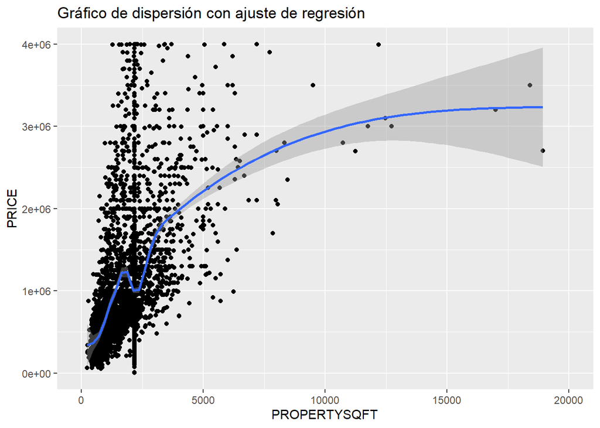

```r
NYHouse |>
  ggplot(aes(x = PROPERTYSQFT, y = PRICE)) +
  geom_point() +
  geom_smooth() +
  labs(title = "Gráfico de dispersión con ajuste de regresión") +
  ylim(0, 4000000) + xlim(0 , 20000)
```

Como ya esperábamos tras el estudio de correlación lineal, el análisis de estas dos variables no es nada sencillo. Lo primero a comentar, al igual que pasó con ambas variables en análisis univariante, la gráfica representada no comprende la totalidad de los valores de ambas variables. De ser así, la gráfica obtenida habría sido ilegible. Esto se debe a que la gran mayoría de valores están situdos entre los límites establecidos en esta gráfica.

Es claramente observable, gracias al ajuste de regresión elaborado automáticamente por el programa informático, que la regresión obtenida en este estudio no corresponde a ningún polinomio conocido, devolviéndonos el programa un gráfico muy complejo de analizar. La información rescatada de la línea de regresión se puede interpretar como una tendencia ascendente en un principio, que al alcanzar el valor aproximado de 1750 pies cuadrados se convierte en una descendente. A su vez, a la la altura aproximada de 2250 pies cuadradros esta tendencia descendente se transforma en una ascendente de nuevo. Esta tendencia ascendente se empieza a difuminar a la altura aproximada de 3000 pies cuadrados, convirtiéndose finalmente en una curva difusa de tendencia ascendente.

Como información extra, se puede apreciar una agrupación de puntos formando una línea vertical. Esto nos recuerda al análisis univariante de la variable ubicada en el eje de las abscisas, llamada PROPERTYSQFT. En éste veíamos como la gran mayoría de casos se concentraban en un único intervalo (1980 y 2300).

#### Gráfico de dispersión con número de PRICE, PROPRTYSQFT y LOCALITY

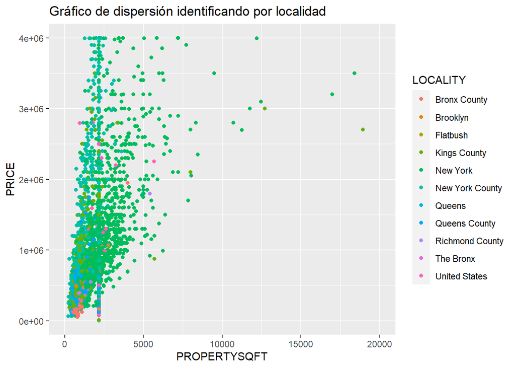

```r
NYHouse |>
  ggplot(aes(x = PROPERTYSQFT, y = PRICE, col = LOCALITY)) +
  geom_point() +
  labs(title = "Gráfico de dispersión identificando por localidad ") +
  ylim(0, 4000000) + xlim(0 , 20000)
```

En este gráfico que observamos que las dos localidades que predominan (como ya vimos en análisis univariante) son New York y New York County. Además, con este gráfico podemos conocer la zona de mayor concentración de estos valores según el precio y los pies cuadrados de cada casa. Estos valores son aproximadamente: a partir de 500000 hasta 2500000 dólares y a partir de 1250 hasta 5000 pies cuadrados para New York; y a partir de 500000 hasta 4000000 dólares y a partir de 0 hasta 2500 pies cuadrados para New York County.

#### Gráfico de dispersión con número de PRICE, PROPRTYSQFT y SUBLOCALITY

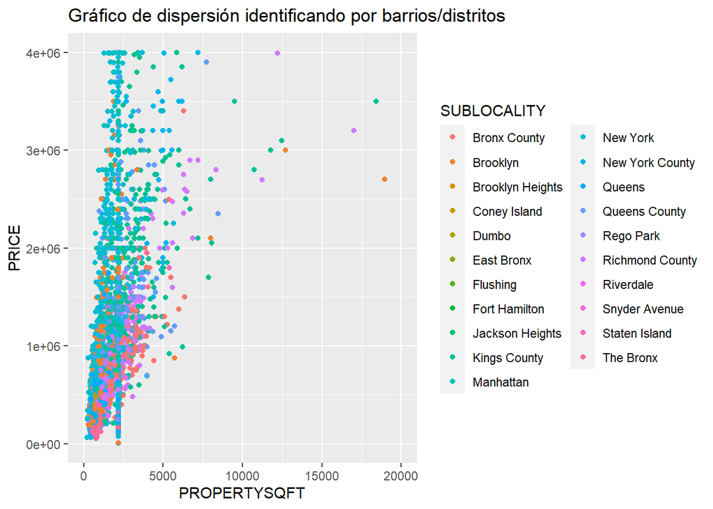

```r
NYHouse |>
  ggplot(aes(x = PROPERTYSQFT, y = PRICE, col = SUBLOCALITY)) +
  geom_point() +
  labs(title = "Gráfico de dispersión identificando por barrios/distritos") +
  ylim(0, 4000000) + xlim(0 , 20000)
```

En este gráfico que observamos que los dos barrios/distritos que predominan (como ya vimos en análisis univariante) son New York y Kings County. Además, con este gráfico podemos conocer la zona de mayor concentración de estos valores según el precio y los pies cuadrados de cada casa. Estos valores son aproximadamente: a partir de 500000 hasta 4000000 dólares y a partir de 0 hasta 2500 pies cuadrados para New York; y a partir de 1000000 hasta 3000000 dólares y a partir de 2500 hasta 5000 pies cuadrados para Kings County.

De todos modos, con ambas gráficas podemos hacernos una gran idea de la cantidad de precio y pies cuadrados que suelen tener las casas en cada localidad y barrio/distrito, hasta un valor de 4000000 de dólares y 20000 pies cuadrados (donde se ubica la gran mayoría valores obtenidos).

# Conclusión

Después de haber realizado el análisis exploratorio de datos podemos llegar a las siguientes conclusiones:

- Además de lo mencionado en la introducción, se han descartado el análisis univariante de algunas variables debido a su complejidad o poca utilidad. No solamente ha sido en el análisis univariante, sino que también han sido numerosas las posibilidades de estudio que han resultado descartadas. Esto se ha debido a la infinidad de posibilidades que teníamos disponibles y la escasa información que éstas nos proporcionaban.
- Aun así hay varias variables que han tenido una buena correlación lineal entre ellas. La correlación más clara ha sido la de las variables BEDS y BATH, que han sido debidamente analizadas.
- Por último, nuestro principal objetivo no se ha podido llevar a cabo debido a que tras el análisis de correlación numérica, todas las variables que tenían un posible estudio con el precio, representaban un valor de correlación lineal muy cercano a cero. Esto imposibilitaba su análisis. De todos modos hemos realizado el estudio del principal objetivo, con resultados no muy óptimos.